# Gas Flux Data Analysis: Trends So Far

2025-02-19

# Looking at the Data

My first step was to read in the data from this summer ([Visit Level Data Master](https://docs.google.com/spreadsheets/d/1bEeLGy_V4fCCAN53Vip1kEdjaSbTmMk9R6YeXoFD9Yw/edit?usp=sharing) - in Research/Beavers/AWA Beaver Project/Data). My R scripts for processing the data are in Research/Beavers/AWA Beaver Project/R Scripts and on Github [here](https://github.com/Spencer-D-Johnson/Gas_Flux); I entered the data from the data sheets manually, used ‘gas.flux.start.end.time.plotting.R’ to find the intervals for slope calculations, then ran ‘Gas_flux_calculations.R’ to calculate the rest.

I’ve separated out light and dark measurements to get photosynthesis and respiration. I’m assuming that the collar respiration rate is the CO2 flux from the dark measurement, and the collar photosynthesis rate (Gross Primary Production) is the CO2 flux from light (Net Primary Production) minus the CO2 flux from dark. There are complications to this setup, of course: our immediate on/off switch with the plastic bags may not perfectly represent base respiration, particularly at night (for example, [one recent paper](https://www.nature.com/articles/s43247-024-01312-y) suggests that respiration declines throughout the night). And differences in other conditions between light and dark (like temperature) may cause some error in the photosynthesis rate. Still, these approximations are the best we have.

```r
# Load packages
library(tidyverse)  # tidy data processing and ggplot
library(mgcv)  # for GAMs
library(GGally)  # correlation plot
library(viridis)  # color schemes
library(gratia)  # Plotting smooths from GAMs
library(knitr)  # kable() for tables
theme_set(theme_bw())  # use black and white theme for plots

# Read in master .csv, convert categorical variables to factors
visit = read.csv("Visit Level Data Master.csv")
visit = visit %>% filter(Flag != "Extra" & Flag != "Extra_Pair") # Get rid of extra measurements
visit$CollarID = as.factor(visit$CollarID)
visit$Site = as.factor(visit$Site)

# Calculate decimal hours to see if time of day matters; might be useful to use lux sensors or other data source to calculate time since sunrise
visit$dec.hrs = hour(hms(visit$Time_Seal)) + (minute(hms(visit$Time_Seal))/60)

# Separate out light measurements
light = visit %>%
  filter(Light_Dark == "Light")
# Separate out dark measurements
dark = visit %>%
  filter(Light_Dark == "Dark")
# Calculate photosynthesis by subtracting dark from light for corresponding measurements (assumes respiration rate is constant between light and dark measurements)
photo = data.frame(CollarID = light$CollarID,
                   Date = light$Date,
                   Site = light$Site,
                   Photosynthesis_umolCO2_m.2_s.1 = light$CO2_flux_umol_m.2_sec.1 - dark$CO2_flux_umol_m.2_sec.1)

photo_join = light %>% inner_join(photo, by = c("CollarID", "Date", "Site"))
photo_join$CollarID = as.factor(photo_join$CollarID)
photo_join$Site = as.factor(photo_join$Site)
```

## Gas Flux Across Time

### CO2 Flux

#### Net Exchange (Light Measurements)

Here you can see the CO2 flux for light measurements ($\mu mol/(m^2s)$). Time is represented as the number of days since the average soil thaw date (May 2nd). The red line shows when we started our dam build/repair.

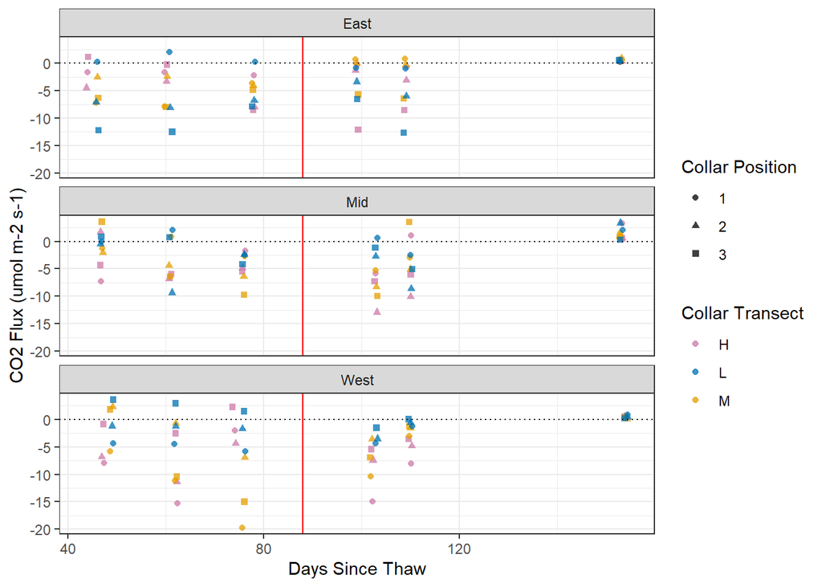

```r
ggplot(light, aes(x = Days_Since_Thaw, y = CO2_flux_umol_m.2_sec.1, color = str_sub(CollarID, start = -2L, end = -2L), shape = str_sub(CollarID, start = -1L, end = -1L))) +
  geom_jitter(size = 1.5, alpha = 0.75) +
  labs(color = "Collar Transect", shape = "Collar Position", x = "Days Since Thaw", y = "CO2 Flux (umol m-2 s-1)") +
  scale_color_manual(values = c("#CC79A7","#0072B2","#E69F00")) +
  geom_vline(xintercept = 88, color = "red") +
  geom_hline(yintercept = 0, lty = "dotted") +
  facet_wrap(~Site, ncol = 1)
```

Most (though not all) of the light measurement fluxes are negative, which indicates a net drawdown of CO2. We see the greatest drawdown at certain collars with tall grass at Tim West.

#### Respiration (Dark):

Next, I plotted CO2 flux for dark measurements, primarily showing cellular respiration within the collars. A small amount of CO2 is likely being converted to CH4; there may be other processes at play as well.

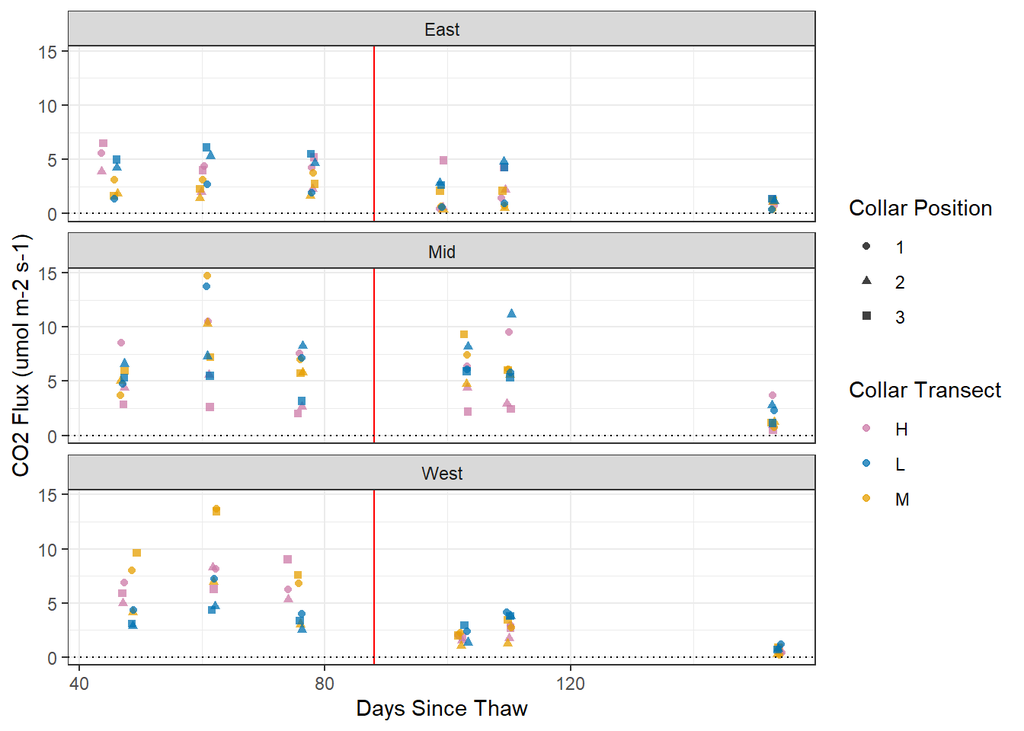

```r
ggplot(dark, aes(x = Days_Since_Thaw, y = CO2_flux_umol_m.2_sec.1, color = str_sub(CollarID, start = -2L, end = -2L), shape = str_sub(CollarID, start = -1L, end = -1L))) +
  geom_jitter(size = 1.5, alpha = 0.75) +
  labs(color = "Collar Transect", shape = "Collar Position", x = "Days Since Thaw", y = "CO2 Flux (umol m-2 s-1)") +
  scale_color_manual(values = c("#CC79A7","#0072B2","#E69F00")) +
  geom_vline(xintercept = 88, color = "red") +
  geom_hline(yintercept = 0, lty = "dotted") +
  facet_wrap(~Site, ncol = 1)
```

Pre-dam, respiration was often higher at Mid and West than at East, where the soil is constantly saturated. However, after our dam work, respiration went down considerably at West, and nearly reached zero at certain East collars. By early October, there was virtually no respiration at East and West, and little respiration (though slightly more) at Mid.

#### Photosynthesis

Here’s what we assume to be photosynthetic flux (light minus dark):

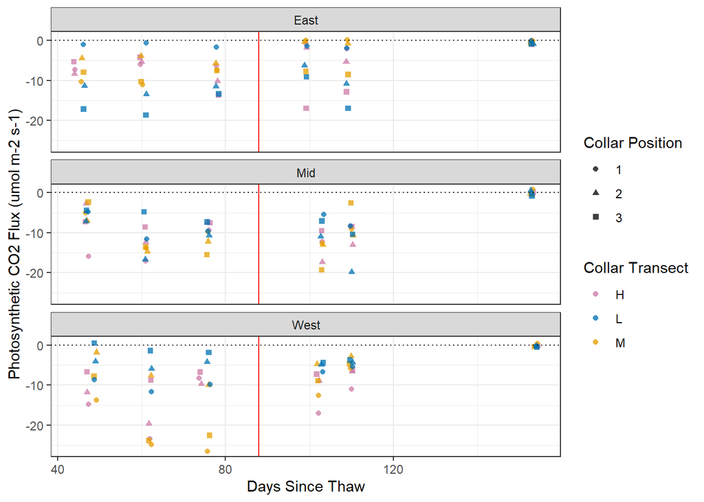

```r
ggplot(data = light %>% inner_join(photo, by = c("CollarID", "Date", "Site")),
       aes(x = Days_Since_Thaw, y = Photosynthesis_umolCO2_m.2_s.1, color = str_sub(CollarID, start = -2L, end = -2L), shape = str_sub(CollarID, start = -1L, end = -1L))) +
  geom_jitter(size = 1.5, alpha = 0.75) +
  labs(color = "Collar Transect", shape = "Collar Position", x = "Days Since Thaw", y = "Photosynthetic CO2 Flux (umol m-2 s-1)") +
  scale_color_manual(values = c("#CC79A7","#0072B2","#E69F00")) +
  geom_vline(xintercept = 88, color = "red") +
  geom_hline(yintercept = 0, lty = "dotted") +
  facet_wrap(~Site, ncol = 1)
```

Photosynthesis rates were a little higher in midsummer for certain collars at West, but overall were fairly consistent (though variable) from June through August. By early October, there was no meaningful photosynthesis occurring. I’m not sure what to make of the slightly positive photosynthetic fluxes (the highest is ~0.8 $\mu mol/(m^2s)$). In the modelling below, I take these at face value and chalk them up to imprecise measurements; I don’t see what would cause more CO2 output in the light measurements than the dark measurements except for maybe temperature, which would be a flaw in our assumption that light and dark measurements have no meaningful environmental differences outside of the light level.

### CH4 Flux

This next graph shows the raw methane flux values:

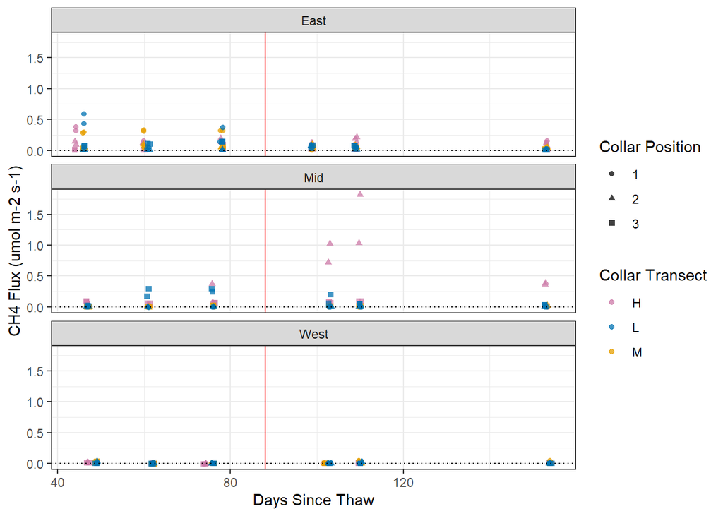

```r
ggplot(data = visit,
       aes(x = Days_Since_Thaw, y = CH4_flux_umol_m.2_sec.1, color = str_sub(CollarID, start = -2L, end = -2L), shape = str_sub(CollarID, start = -1L, end = -1L))) +
  geom_jitter(size = 1.5, alpha = 0.75) +
  labs(color = "Collar Transect", shape = "Collar Position", x = "Days Since Thaw", y = "CH4 Flux (umol m-2 s-1)") +
  scale_color_manual(values = c("#CC79A7","#0072B2","#E69F00")) +
  geom_vline(xintercept = 88, color = "red") +
  geom_hline(yintercept = 0, lty = "dotted") +
  facet_wrap(~Site, ncol = 1)
```

Methane flux is relatively high at East, and much lower at West. Production increased drastically in August at one collar at Mid (TMH2). That collar is near a stagnant pool, which may be a contributing factor. If I remove that collar and free the scales for the subplots, we can see more detail:

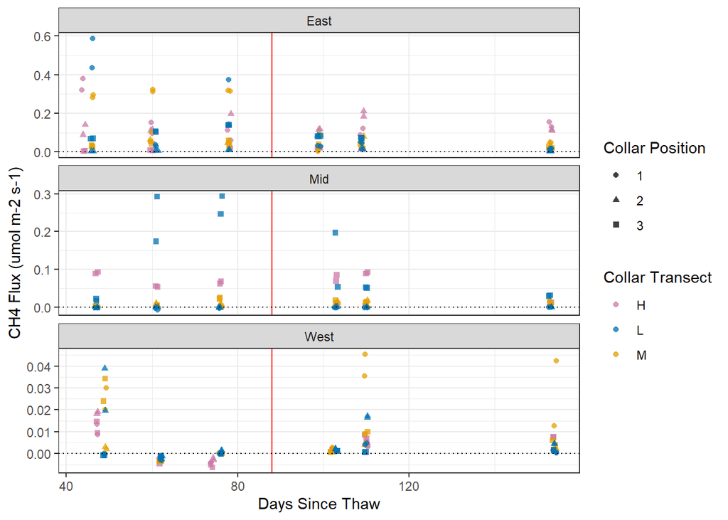

```r
ggplot(data = visit %>% filter(CollarID != "TMH2"),
       aes(x = Days_Since_Thaw, y = CH4_flux_umol_m.2_sec.1, color = str_sub(CollarID, start = -2L, end = -2L), shape = str_sub(CollarID, start = -1L, end = -1L))) +
  geom_jitter(size = 1.5, alpha = 0.75) +
  labs(color = "Collar Transect", shape = "Collar Position", x = "Days Since Thaw", y = "CH4 Flux (umol m-2 s-1)") +
  scale_color_manual(values = c("#CC79A7","#0072B2","#E69F00")) +
  geom_vline(xintercept = 88, color = "red") +
  geom_hline(yintercept = 0, lty = "dotted") +
  facet_wrap(~Site, ncol = 1, scales = "free_y")
```

At East, there’s been a drop in methane production since the dam went in, mostly at certain collars that are now in deeper water. Methane production mostly occurs at a few collars at Mid, and dropped at these collars in October. At West, the absolute production levels are small, but you can really see the combined effects of water levels and time. Methane production was higher early in the season when the water level was high but swiftly dropping (the site had been flooded since breakup). Methane was being slowly consumed on net in early July, and production was still basically 0 just after a rain event in mid-July despite the site being flooded again. Methane production was higher in the third week of August than the second week despite lower water levels - presumably because having been flooded for longer, more of the site was anoxic, or the anoxic conditions had persisted long enough for more methanogens to grow.

## Water Level

Here’s a plot of water levels from our piezometers across the summer. Water levels are shown with respect to the ground surface (positive = standing water).

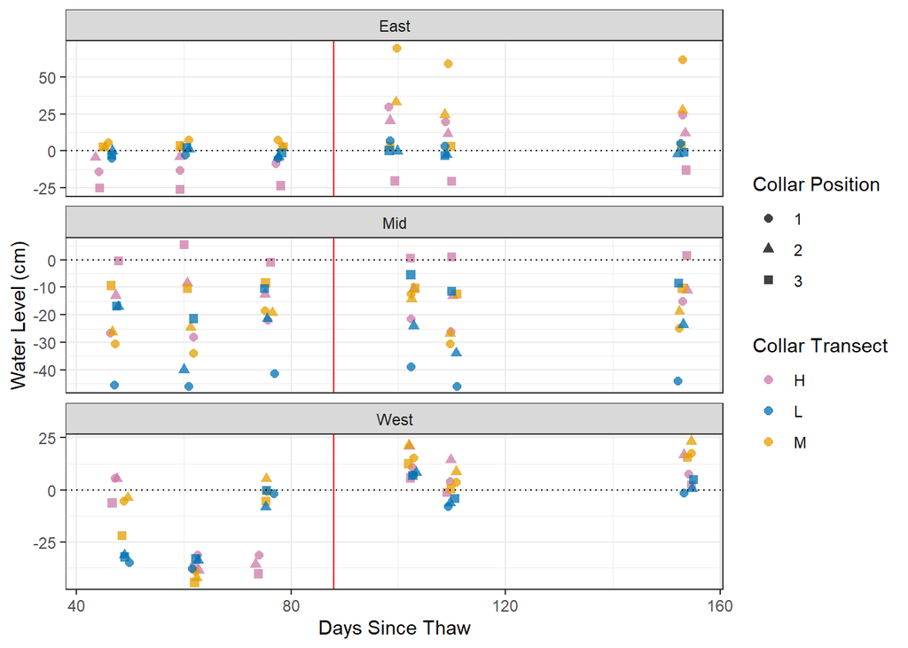

```r
ggplot(light, aes(x = Days_Since_Thaw, y = Water_Level_cm, color = str_sub(CollarID, start = -2L, end = -2L), shape = str_sub(CollarID, start = -1L, end = -1L))) +
  geom_jitter(size = 2, width = 1, height = 0, alpha = 0.75) +
  geom_vline(xintercept = 88, color = "red") +
  geom_hline(yintercept = 0, lty = "dotted") +
  scale_color_manual(values = c("#CC79A7","#0072B2","#E69F00")) +
  facet_wrap(~Site, ncol = 1, scales = "free_y") +
  labs(color = "Collar Transect", shape = "Collar Position", x = "Days Since Thaw", y = "Water Level (cm)")
```

You can see that nothing changes that much across the summer and fall at the mid site. East has consistently high-ish water levels throughout (probably because of the impermeable soil), but after the dam work, certain collars that are now in the pond have much higher water. West is the flashiest site, but since putting in the BDA the water levels have been consistently high.

## Vegetation

We’ve collected a lot of vegetation data for the beaver project. Here, I look at two general categories of vegetation variables. The first is biomass. You would expect that vegetation biomass would have a significant effect on at least photosynthesis and respiration rates, and we can calculate a rough biomass proxy by combining June 2024 percent covers with visit-level max vegetation heights. The second category is percent cover by vegetation type (e.g., herbaceous, woody, potential methane straw). We have a limited number of collars, and vegetation types are largely similar within sites, so these variables may have limited utility, but I wanted to examine them anyway. The next step would be to ordinate the veg communities and plot them with gas flux variables to look for additional patterns. I think Rhiannon is working on that step.

### Biomass

There are a number of approaches for calculating biomass. Originally, I was just doing top cover * max height, which makes some sense - it’s simple, and top cover may be more representative of photosynthetically relevant plant material than total cover. However, I figured the cover part could be improved a bit by taking out bryophyte cover (too small to contribute meaningfully to photosynthesis), and I wasn’t sure whether top cover or total cover would make more sense. I also thought the height estimate could potentially be improved by separating out woody vs herbaceous cover, and matching those to max woody and herbaceous heights. I tried 6 total formulations:

1. bm1 = top cover * max height
2. bm2 = non-bryophyte top cover * max height
3. bm3 = top woody cover * max woody height + top herbaceous cover * max herbaceous height
4. bm4 = total cover * max height
5. bm5 = total non-bryophyte cover * max height
6. bm6 = total woody cover * max woody height + total herbaceous cover * max herbaceous height

I plotted each of these with respect to each other and to photosynthetic flux for June and July measurements - ie., when the most photosynthesis was happening, and before the dam work (which complicates the data):

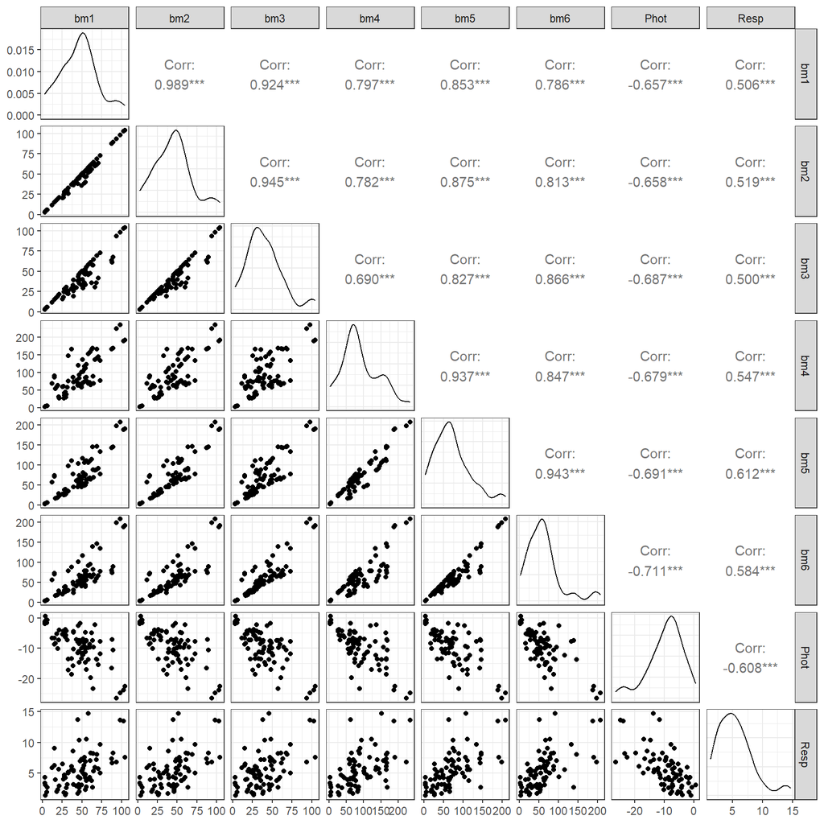

```r
# Bring in veg type data
gpi = read.csv("beaver_GPI_full.csv") # total foliar cover (multilayer)
top = read.csv("beaver_GPI_top.csv") # just top foliar cover
ref = read.csv("veg_ref.csv") %>% rename(Species_Name = name) # functional group reference table

# Define CollarID variable as factor (separate out month)
gpi$CollarID = as.factor(substr(gpi$site_visit_code, 1, 4))
top$CollarID = as.factor(substr(top$Site, 1, 4))

# Look at ACCS veg functional groups, add functional groups to top cover data
# unique(gpi$analysis_name)
top = top %>% left_join(ref[,1:2], by = "Species_Name")
# top %>% filter(is.na(fn_gr)) # solved NA issues
# unique(top$fn_gr)

# Redefine simpler veg categories (try 2 different schemes)
gpi$simple_cats = fct_collapse(gpi$analysis_name, # More detailed scheme
                                    tall_woody = "shrub",
                                    dwarf_woody = c("dwarf shrub", "dwarf ericaceous shrub"), # separate out dwarf since dwarf shrubs probably have minimal effect on photosynthesis
                                    graminoid = c("grass", "sedge"),
                                    forb = c("forb", "horsetail", "clubmoss"),
                                    moss = c("sphagnum moss","acrocarpous moss","feathermoss","moss"))
gpi$simple_cats2 = fct_collapse(gpi$analysis_name, # Less detailed scheme
                                    woody = c("shrub", "dwarf shrub", "dwarf ericaceous shrub"),
                                    herb = c("grass", "sedge", "forb", "horsetail", "clubmoss"),
                                    moss = c("sphagnum moss","acrocarpous moss","feathermoss","moss"))
top$simple_cats2 = fct_collapse(top$fn_gr, # Less detailed scheme
                                    woody.t = c("shrub", "dwarf shrub", "dwarf ericaceous shrub"),
                                    herb.t = c("grass", "sedge", "forb", "horsetail"),
                                    moss.t = c("sphagnum moss","acrocarpous moss","feathermoss","moss"))

# Define high-methane species - based on Rhiannon's research so far, and assuming Carex utriculata and all horsetails are methane straws
gpi$methane_cats = fct_collapse(gpi$akvegcode,
                                high_CH4 = c("carutr","compal","equarv","equflu","equsyl"),
                                other_level = "other_CH4")

# Filter to live vegetation in June 2024
gpi.lj = gpi %>% filter(dead_status == "FALSE",
                        substr(site_visit_code, 6, 12) == "Jun2024")
top.lj = top %>% filter(dead_status == "FALSE",
                        substr(Site, 6, 12) == "Jun2024")

# Get summaries of all the different cover variables, put them into one table, join with the table with all the data
sum1 = gpi.lj %>% group_by(CollarID, simple_cats) %>%
  summarise(cover = sum(cover_percent)) %>% pivot_wider(names_from = simple_cats, values_from = cover, values_fill = 0)
sum2 = gpi.lj %>% group_by(CollarID, simple_cats2) %>%
  summarise(cover = sum(cover_percent)) %>% pivot_wider(names_from = simple_cats2, values_from = cover, values_fill = 0)
sum3 = gpi.lj %>% group_by(CollarID, methane_cats) %>%
  summarise(cover = sum(cover_percent)) %>% pivot_wider(names_from = methane_cats, values_from = cover, values_fill = 0)
sum4 = top.lj %>% group_by(CollarID, simple_cats2) %>%
  summarise(cover = sum(Percent_Foliar_Cover)) %>% pivot_wider(names_from = simple_cats2, values_from = cover, values_fill = 0)
cover_sum = sum1 %>% inner_join(sum2) %>% inner_join(sum3) %>% inner_join(sum4) %>% select(-c(other_CH4))
visit = visit %>% inner_join(cover_sum, by = "CollarID")
visit = visit %>% mutate(bare = 100 - woody.t - herb.t - moss.t)

# Calculate 6 possible forms of biomass; use proportions rather than percents
visit$bm1 = (visit$woody.t + visit$herb.t + visit$moss.t)*visit$Max_Ht_cm/100
visit$bm2 = (visit$woody.t + visit$herb.t)*visit$Max_Ht_cm/100
visit$bm3 = apply(cbind(visit$woody.t*visit$Max_Ht_Wood_cm, visit$herb.t*visit$Max_Ht_Herb_cm),1,sum,na.rm = TRUE)/100
visit$bm4 = (visit$woody + visit$herb + visit$moss)*visit$Max_Ht_cm/100
visit$bm5 = (visit$woody + visit$herb)*visit$Max_Ht_cm/100
visit$bm6 = apply(cbind(visit$woody*visit$Max_Ht_Wood_cm, visit$herb*visit$Max_Ht_Herb_cm),1,sum,na.rm = TRUE)/100
# Average light and dark methane
methane.avg = visit %>% group_by(CollarID, Date, bm1, bm2, bm3, bm4, bm5, bm6) %>% summarise(mean_CH4_flux = mean(CH4_flux_umol_m.2_sec.1))

# Put photosynthesis, respiration, avg methane into one table with biomass variables, plot correlations.
biom = photo %>% inner_join(dark) %>%
  inner_join(methane.avg) %>%  # leave out methane flux data for final graph - not as relevant
  filter(as.integer(substr(Date,1,1)) %in% 6:7) %>%  # summer readings before dam work
  select(c(bm1, bm2, bm3, bm4, bm5, bm6, Photosynthesis_umolCO2_m.2_s.1, CO2_flux_umol_m.2_sec.1)) %>%
  rename(Phot = Photosynthesis_umolCO2_m.2_s.1, Resp = CO2_flux_umol_m.2_sec.1)

# Set biomass proxy
visit$Biomass = visit$bm5
visit = visit %>% select(-c(bm1,bm2,bm3,bm4,bm5,bm6))
visit$log.Biomass = log(visit$Biomass)  # for later modelling

ggpairs(biom) # All pretty similar performance for photosynthesis and respiration; Looks like total veg cover is a little better than top cover (especially for respiration); removing mosses is maybe a little better than not, but no clear conclusion; split woody-herbaceous heights not clearly better or worse; simpler is probably better so maybe go with total cover with no moss (bm5)? Removing moss would make sense.
```

All of these biomass proxies are quite similar to each other, unsurprisingly. Top cover and total cover show some separation from each other, but within these broader categories the specifics don’t matter that much. In general, it seems like total cover is a little better correlated with CO2 flux than top cover - particularly with respiration. Non-bryophyte total cover and split woody-herbaceous total cover seem like the best options; the former is slightly more correlated with respiration, while the latter is slightly more correlated with photosynthesis, though the differences are probably too small to matter. **I’ll use non-bryophyte total cover for biomass** moving forward: splitting up woody and herbaceous seems unnecessarily complicated if there’s no clear benefit, but removing bryophytes does make intuitive sense and seems to improve the correlation a little bit for respiration.

### Types of Cover

This next plot shows total percent cover from various categories versus gas flux, again just for June and July 2024. The categories shown are moss (equivalent to “bryophyte” for these sites), forb, graminoid, woody, “tall woody” (dwarf shrubs might create noise in the woody shrub effect), herbaceous, bare, and “High CH4”. High CH4 includes the species that Rhiannon has flagged as potential methane straws - *Carex utriculata*, *Comarum palustre*, and *Equisetum arvense* - as well as the other horsetails (*E. fluviatile* and *E. sylvaticum*).

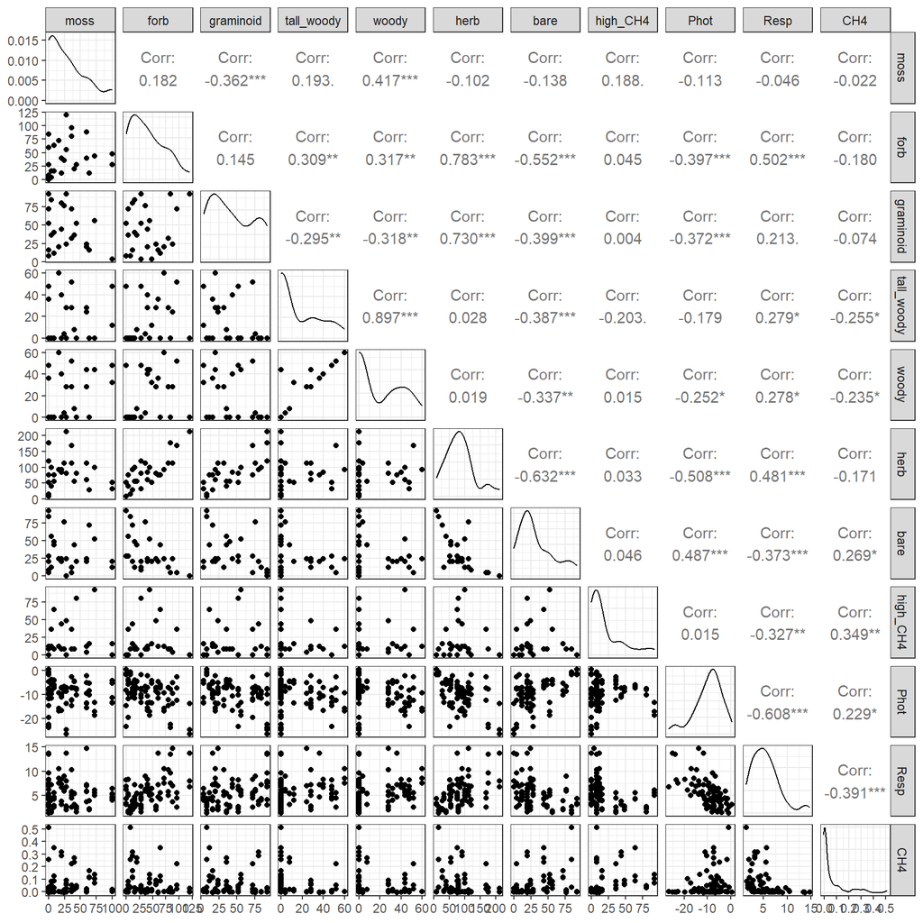

```r
# Plot various types of total cover vs gas flux
cover = photo %>% inner_join(visit %>% filter(Light_Dark == "Dark")) %>%
  inner_join(methane.avg) %>%
  filter(as.integer(substr(Date,1,1)) %in% 6:7) %>%  # again, just look at June and July
  select(c(moss, forb, graminoid, tall_woody, woody, herb, bare, high_CH4, Photosynthesis_umolCO2_m.2_s.1, CO2_flux_umol_m.2_sec.1, mean_CH4_flux)) %>%
  rename(Phot = Photosynthesis_umolCO2_m.2_s.1, Resp = CO2_flux_umol_m.2_sec.1, CH4 = mean_CH4_flux)

ggpairs(cover) # photosynthesis: strongest relationship with %herb; respiration: strongest with %forb weirdly, similar with %herb overall; CH4: strongest relationship is with %high_CH4, MAYBE slight negative relationship with %woody; all of these may be (likely to be) confounded with other variables (esp. site)
```

There’s a lot to process here. Photosynthesis is somewhat correlated to %forb, %graminoid, %herbaceous, and %bare. Percent herbaceous has the highest correlation, and is probably the most robust variable to use between the first three. Both %herbaceous and %bare are probably highly related to biomass. Respiration has its highest correlation with %forb - maybe because forbs are more correlated to dry ground than graminoids? - but the correlation with %herbaceous is similar; again, %bare has a highly significant correlation. For methane, all of the correlations are lower. The highest correlation is, unsurprisingly, with %high CH4 species. It’s also worth looking more closely at the scatterplots: for modelling with GAMs, we don’t *necessarily* care about linear correlations so much as smooth relationships between variables. For example, %high CH4 has weak to nonexistent linear relationships with photosynthesis and respiration, but it looks like smooth curve fits could work a little better.

I’ll consider **%herbaceous, %bare, and %high CH4 species** moving forward. I suspect all of these variables may be too correlated to other variables to provide much information, but we’ll see. It’s worth noting that vegetation variables might be more useful if we didn’t have as many other environmental variables, like water level. The New England gas flux researchers at the Annual Meeting made the point that plants integrate a lot of other environmental conditions.

## Light

### 2024 Overview

Here’s a plot of light intensity (Lux) at each collar across all 2024 light measurements:

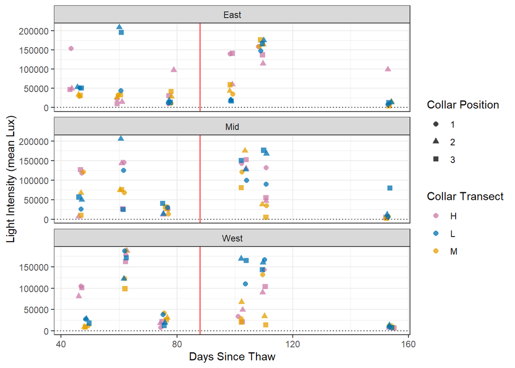

```r
ggplot(light, aes(x = Days_Since_Thaw, y = Mean_Lux, color = str_sub(CollarID, start = -2L, end = -2L), shape = str_sub(CollarID, start = -1L, end = -1L))) +
  geom_jitter(size = 2, width = 1, height = 0, alpha = 0.75) +
  geom_vline(xintercept = 88, color = "red") +
  geom_hline(yintercept = 0, lty = "dotted") +
  scale_color_manual(values = c("#CC79A7","#0072B2","#E69F00")) +
  facet_wrap(~Site, ncol = 1, scales = "free_y") +
  labs(color = "Collar Transect", shape = "Collar Position", x = "Days Since Thaw", y = "Light Intensity (mean Lux)")
```

Light obviously varies on a time-of-day and week to week basis - the middle of July must have been cloudy, for example. Light was MUCH lower in October for most collars.

### Lux vs PAR and considering angle

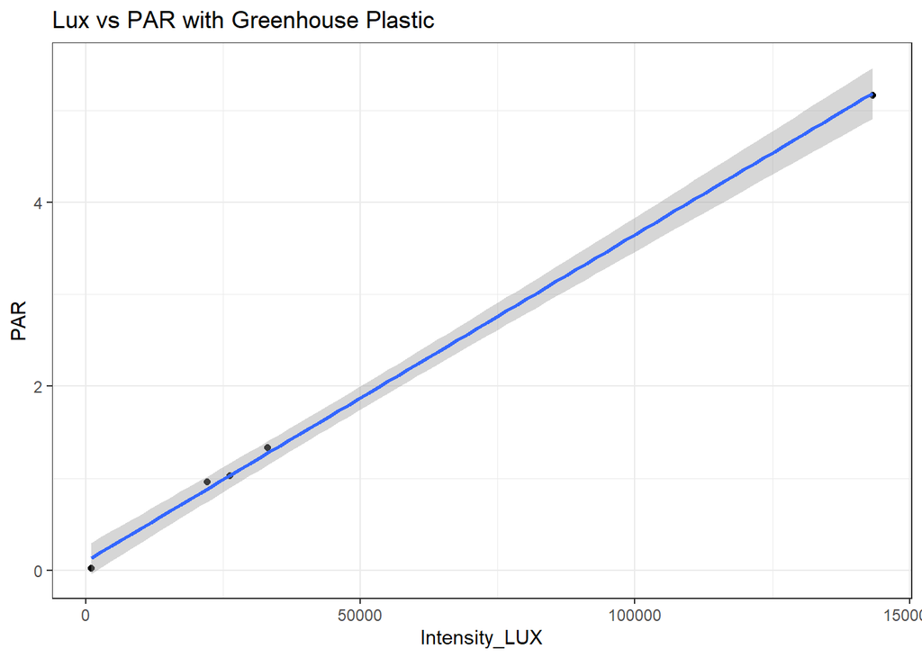

```r
# read in data
full_swmp = read.csv("Homet_8-23-24.csv") %>% rename(time = DateTimeStamp)  # swmp data (ambient PAR)
par_plastic = read.csv("Homet_8-23-24_PAR_plastic.csv") %>% rename(time = DateTimeStamp)  # Spencer's written PAR data with plastic (from swmp sensor)
lux = read.csv("Homet_8-23-24_lux.csv") %>% rename(time = Date.Time..GMT.09.00)  # lux data from pendant sensor

# Join lux and PAR data from plastic experiment
plastic = lux %>% inner_join(par_plastic, by = "time")

ggplot(plastic, aes(x = Intensity_LUX, y = PAR)) +
  geom_point() +
  geom_smooth(method = "lm") +
  labs(title = "Lux vs PAR with Greenhouse Plastic")
```

```r
# run model, summarize and get confidence interval
mod.plastic = lm(PAR ~ Intensity_LUX, data = plastic)
summary(mod.plastic)
```

```
##
## Call:
## lm(formula = PAR ~ Intensity_LUX, data = plastic)
##
## Residuals:
##          1          2          3          4          5
## -0.0253242 -0.1137522  0.0786282 -0.0002659  0.0607141
##
## Coefficients:
##                Estimate Std. Error t value Pr(>|t|)
## (Intercept)   9.784e-02  5.313e-02   1.842    0.163
## Intensity_LUX 3.554e-05  7.868e-07  45.169 2.39e-05 ***
## ---
## Signif. codes:  0 '***' 0.001 '**' 0.01 '*' 0.05 '.' 0.1 ' ' 1
##
## Residual standard error: 0.08841 on 3 degrees of freedom
## Multiple R-squared:  0.9985, Adjusted R-squared:  0.998
## F-statistic:  2040 on 1 and 3 DF,  p-value: 2.389e-05
```

```r
confint(mod.plastic)
```

```
##                       2.5 %       97.5 %
## (Intercept)   -7.123039e-02 2.669172e-01
## Intensity_LUX  3.303443e-05 3.804224e-05
```

We see an almost perfect linear relationship with the greenhouse plastic. The slope is $3.55*10^{-5}$, which is similar to the slope for Lux vs PAR below without plastic ($3.79*10^{-5}$):

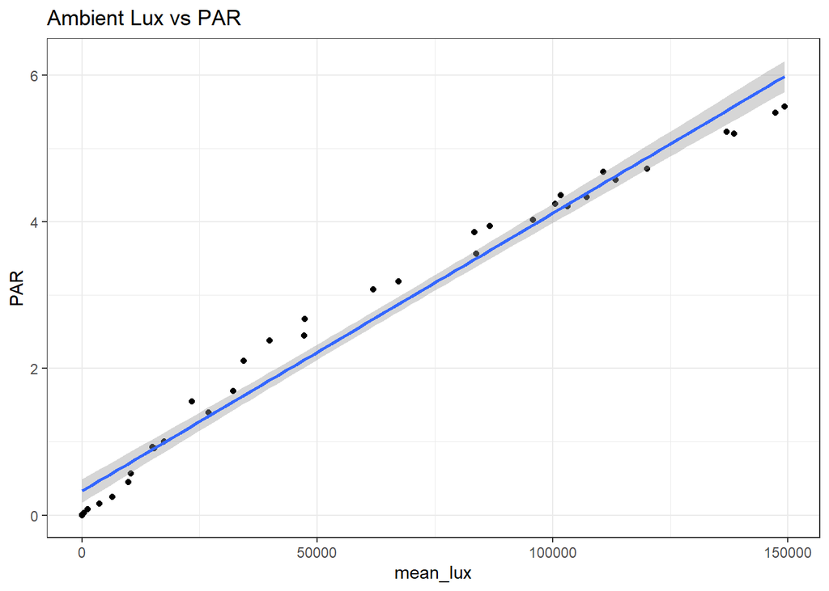

```r
# create period class time column for lux
lux$period = hms(lux$time)
# cut off incomplete/non-ambient time periods for lux
lux_15min = lux %>% filter(period > "12H 30M 0S" & period <= "21H 30M 0S")
# create column with a different integer value for each 15 minute interval
lux_15min$intervals = ceiling((1:nrow(lux_15min))/90)
# Get table with 15 minute interval times from lux data, add interval number to join with summarized data below
indices = seq(90, nrow(lux_15min), 90)
swmp.times = lux_15min[indices, ]
swmp.times$intervals = seq(1, nrow(lux_15min)/90, 1)

# Get mean lux for each 15 minute interval
lux_15min = lux_15min %>%
  group_by(intervals) %>%
  summarise(mean_lux = mean(Intensity_LUX),
            mean_temp = mean(Temp_C)) %>%
  inner_join(swmp.times, by = "intervals")

# convert from total PAR to instantaneous PAR
full_swmp$PAR = full_swmp$TotPAR/180

# Join lux and PAR data
ambient = lux_15min %>% inner_join(full_swmp, by = "time") %>% select(time, mean_lux, mean_temp, ATemp, PAR)

# Plot lux vs par
ggplot(ambient, aes(x = mean_lux, y = PAR)) +
  geom_point() +
  geom_smooth(method = "lm") +
  labs(title = "Ambient Lux vs PAR")
```

```r
# show linear model with confidence interval
mod.ambient = lm(PAR ~ mean_lux, data = ambient)
summary(mod.ambient)
```

```
##
## Call:
## lm(formula = PAR ~ mean_lux, data = ambient)
##
## Residuals:
##      Min       1Q   Median       3Q      Max
## -0.41888 -0.30213  0.00337  0.20997  0.54900
##
## Coefficients:
##              Estimate Std. Error t value Pr(>|t|)
## (Intercept) 3.296e-01  7.845e-02   4.202 0.000181 ***
## mean_lux    3.789e-05  1.018e-06  37.220  < 2e-16 ***
## ---
## Signif. codes:  0 '***' 0.001 '**' 0.01 '*' 0.05 '.' 0.1 ' ' 1
##
## Residual standard error: 0.2995 on 34 degrees of freedom
## Multiple R-squared:  0.976,  Adjusted R-squared:  0.9753
## F-statistic:  1385 on 1 and 34 DF,  p-value: < 2.2e-16
```

```r
confint(mod.ambient)
```

```
##                    2.5 %       97.5 %
## (Intercept) 1.701982e-01 4.890438e-01
## mean_lux    3.582254e-05 3.996031e-05
```

The problem is, the ambient (non-plastic) relationship between Lux and PAR isn’t linear. This `loess` smoother provides a much cleaner fit:

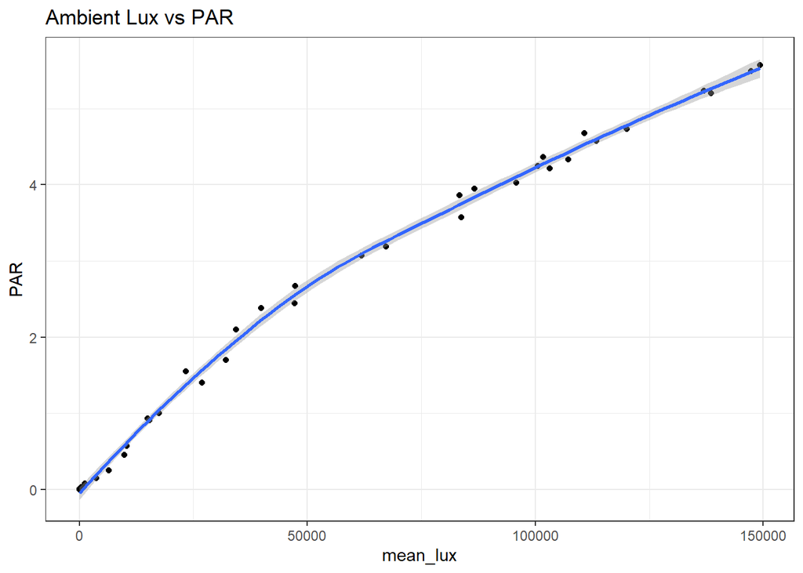

```r
ggplot(ambient, aes(x = mean_lux, y = PAR)) +
  geom_point() +
  geom_smooth(method = "loess") +
  labs(title = "Ambient Lux vs PAR")
```

While I still don’t know exactly why this is, my best guess is the angle of the light. These measurements were taken from midday to sundown, while the measurements with greenhouse plastic were all taken within a short period of time. According to the documentation, the angle of light matters quite a bit for the HOBO Pendant loggers we use for light and temperature; you’re supposed to hang them so that they face direct sunlight. We try to position the gas flux chamber so that the loggers are positioned as close as possible to direct sunlight (Ryan’s suggestion), but our transect loggers definitely are not always oriented toward the sun. At some point, I’d like to re-do this experiment at one of the weather stations; I’d also like to deploy a logger at beaver sites that’s always facing up in an open area to get some comparative full-light data.

### Light vs Dark Methane

I also wanted to test whether there’s any difference between light and dark measurements for methane flux:

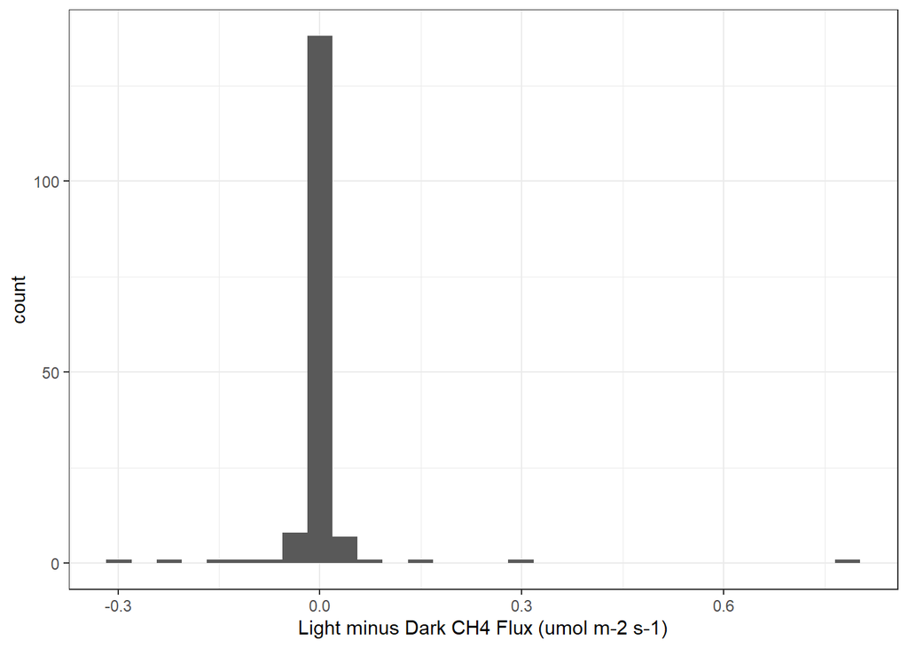

```r
# light minus dark CH4
light_minus_dark = light$CH4_flux_umol_m.2_sec.1 - dark$CH4_flux_umol_m.2_sec.1
# use log values instead
log_light_minus_dark = log(light$CH4_flux_umol_m.2_sec.1 + 0.01) - log(dark$CH4_flux_umol_m.2_sec.1 + 0.01)

ggplot(as.data.frame(light_minus_dark), aes(x = light_minus_dark)) +
  geom_histogram() +
  labs(x = "Light minus Dark CH4 Flux (umol m-2 s-1)")
```

```r
  #xlim(c(-0.01, 0.01))

t.test(log_light_minus_dark) # use log values for t-test
```

```
##
##  One Sample t-test
##
## data:  log_light_minus_dark
## t = -0.075948, df = 161, p-value = 0.9396
## alternative hypothesis: true mean is not equal to 0
## 95 percent confidence interval:
##  -0.04337665  0.04016382
## sample estimates:
##    mean of x
## -0.001606414
```

The histogram shows that there’s no directional trend in methane flux between light and dark, and most of the differences are very small. The results of the t-test confirm that neither light nor dark measurements have consistently higher values (I used log values, but you get the same result either way). Moving forward, I will **average the light and dark measurements** when modelling methane flux.

## Air Temperature

Our air temperature data from the beaver project have some major issues. To get accurate air temperatures from the HOBO Pendant loggers - as with any temperature loggers, I suppose - you’re supposed to always keep them shaded. Unfortunately, this makes it impossible to use the loggers effectively for both temperature and light at the same time. At this point, we are stuck with suboptimal temperature data for our first year of gas flux work. The best solution I’ve thought of is to build a model of temperature anomaly vs Lux, and then apply that model to correct the temperatures. When we ran the experiment at the Homer SWMP station, we also collected temperature data from the Pendant logger, and of course the SWMP station collects temperature. Here are the results (with the dashed line showing a 1:1 relationship):

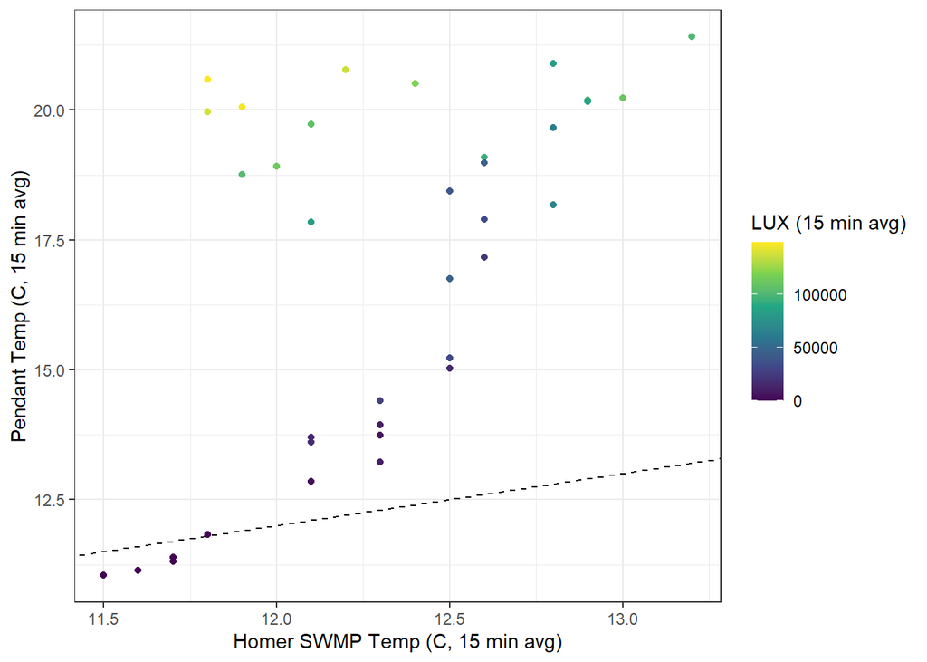

```r
ggplot(ambient, aes(x = ATemp, y = mean_temp, color = mean_lux)) +
  geom_point() +
  scale_color_viridis_c() +
  geom_abline(slope = 1, intercept = 0, lty = "dashed") +
  labs(x = "Homer SWMP Temp (C, 15 min avg)", y = "Pendant Temp (C, 15 min avg)", color = "LUX (15 min avg)")
```

Temperature didn’t vary much at the weather station, but sure enough, you can see that the Pendant sensor’s temperature shoots up when light intensity increases. I tried modelling this using the following GAM: $(Temp_{Pendant}-Temp_{SWMP}) = f(LUX) + \beta$:

```r
gam_temp = gam((mean_temp - ATemp) ~ s(mean_lux), data = ambient)
summary(gam_temp)
```

```
##
## Family: gaussian
## Link function: identity
##
## Formula:
## (mean_temp - ATemp) ~ s(mean_lux)
##
## Parametric coefficients:
##             Estimate Std. Error t value Pr(>|t|)
## (Intercept)    4.606      0.133   34.62   <2e-16 ***
## ---
## Signif. codes:  0 '***' 0.001 '**' 0.01 '*' 0.05 '.' 0.1 ' ' 1
##
## Approximate significance of smooth terms:
##               edf Ref.df     F p-value
## s(mean_lux) 3.243  3.984 130.4  <2e-16 ***
## ---
## Signif. codes:  0 '***' 0.001 '**' 0.01 '*' 0.05 '.' 0.1 ' ' 1
##
## R-sq.(adj) =  0.937   Deviance explained = 94.3%
## GCV = 0.72234  Scale est. = 0.6372    n = 36
```

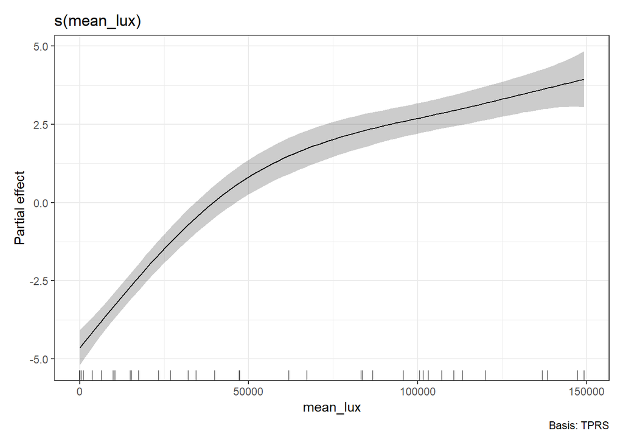

```r
draw(gam_temp)
```

The adjusted $R^2$ is 0.937, which is pretty good! I applied this model to the temperature data from the beaver sites and **will use the adjusted temperatures** moving forward in this analysis. In the future, it would be good to get some more data to back up the relationship - especially from a shaded sensor at the beaver sites themselves that we could compare to the temperatures at the transect sensors. Here’s what the adjusted temperature data look like across the year, with light and dark measurements shown individually:

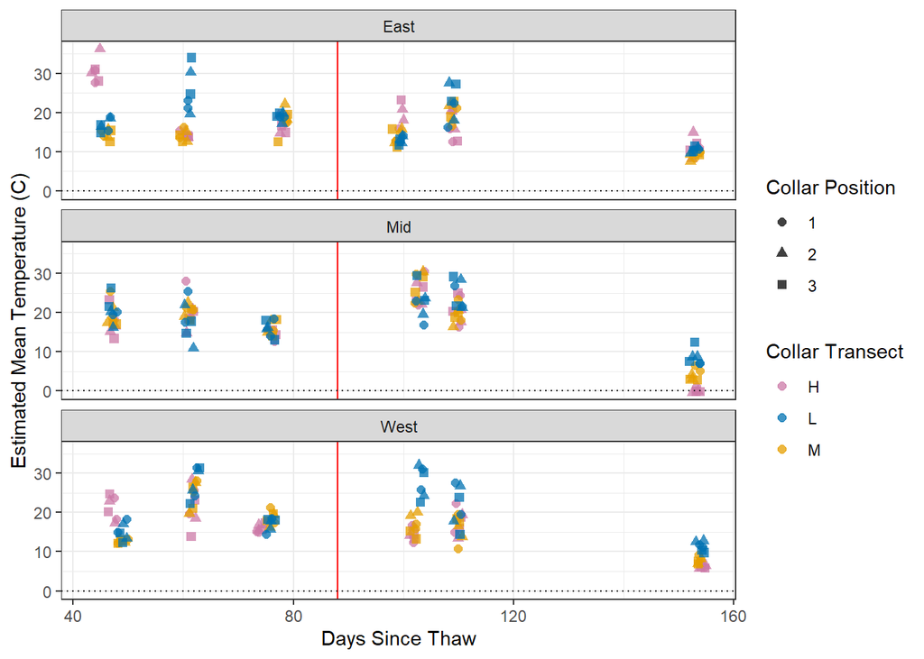

```r
# Add in true temp estimates
## Read in and combine temp/lux data
templux.files = list.files(pattern = "chamber*")
templux.data.separate = lapply(templux.files, read.csv)

# Combine into one table
templux = templux.data.separate[[1]] %>% select(Date, Time_GMT.09.00, Temp_C, Intensity_Lux) %>% drop_na()

for (i in 2:length(templux.data.separate)){
  templux = rbind(templux, templux.data.separate[[i]] %>% select(Date, Time_GMT.09.00, Temp_C, Intensity_Lux) %>% drop_na())
}

templux$Intensity_Lux = as.numeric(templux$Intensity_Lux)  # make lux numeric (rather than character)
templux$Date = mdy(templux$Date)

# Get predictions from GAM for every true temp
temp.preds = predict.gam(gam_temp,  newdata = data.frame(mean_lux = templux$Intensity_Lux))
templux$delta = temp.preds
templux$true_temp = templux$Temp_C - templux$delta

# Create column
visit$Mean_Temp_C_true_estimate = rep(NA, nrow(visit))

# Convert measurement times to period class
visit$ptime.start = hms(visit$Time_Start_Measurement)
visit$ptime.end = hms(visit$Time_End_Measurement)

## Get average temp, lux for measurement periods
for (row in 1:nrow(visit)){
  tl.subset = templux %>% filter(Date == mdy(visit[row, "Date"]) & as.numeric(hms(Time_GMT.09.00)) >= (as.numeric(visit[row, "ptime.start"]) + visit$Hobo_Licor_offset_s[row]) & as.numeric(hms(Time_GMT.09.00)) <= (as.numeric(visit[row, "ptime.end"]) + visit$Hobo_Licor_offset_s[row]))
  visit$Mean_Temp_C_true_estimate[row] = mean(tl.subset$true_temp)
}

ggplot(visit, aes(x = Days_Since_Thaw, y = Mean_Temp_C_true_estimate, color = str_sub(CollarID, start = -2L, end = -2L), shape = str_sub(CollarID, start = -1L, end = -1L))) +
  geom_jitter(size = 2, width = 1, height = 0, alpha = 0.75) +
  geom_vline(xintercept = 88, color = "red") +
  geom_hline(yintercept = 0, lty = "dotted") +
  scale_color_manual(values = c("#CC79A7","#0072B2","#E69F00")) +
  facet_wrap(~Site, ncol = 1) +
  labs(color = "Collar Transect", shape = "Collar Position", x = "Days Since Thaw", y = "Estimated Mean Temperature (C)")
```

Some temperatures are still near or above 30 degrees C, which seems high. However, that might be realistic for temperatures inside the chamber on a sunny day, even if the ambient temperature outside is considerably lower.

## Soil Temperature

And finally, here is how soil temperatures have varied over time:

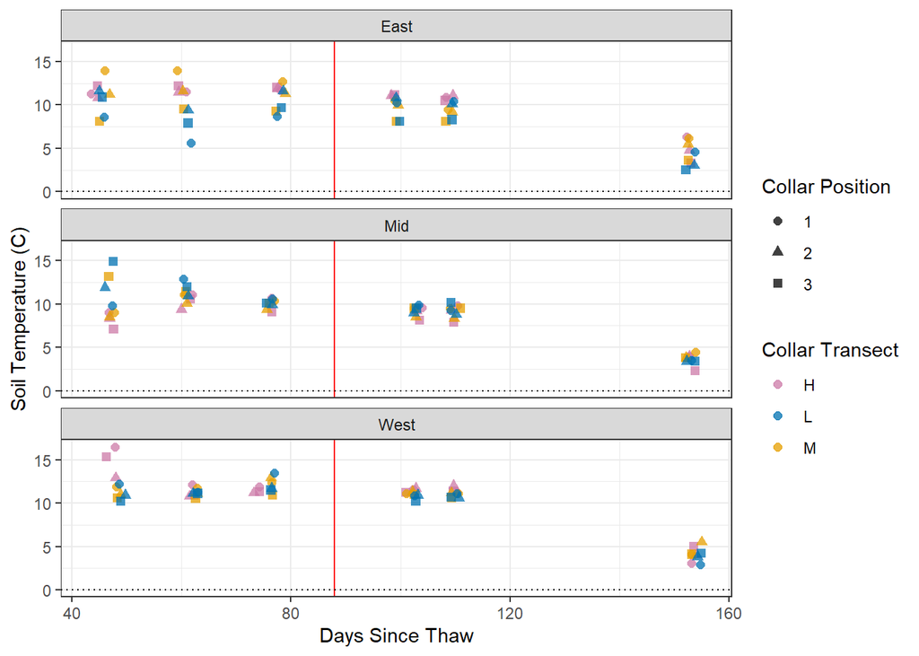

```r
ggplot(light, aes(x = Days_Since_Thaw, y = Soil_Temp_C, color = str_sub(CollarID, start = -2L, end = -2L), shape = str_sub(CollarID, start = -1L, end = -1L))) +
  geom_jitter(size = 2, width = 1, height = 0, alpha = 0.75) +
  geom_vline(xintercept = 88, color = "red") +
  geom_hline(yintercept = 0, lty = "dotted") +
  scale_color_manual(values = c("#CC79A7","#0072B2","#E69F00")) +
  facet_wrap(~Site, ncol = 1) +
  labs(color = "Collar Transect", shape = "Collar Position", x = "Days Since Thaw", y = "Soil Temperature (C)")
```

It looks like some of the hottest soil temperatures were in June, which makes some sense given the hot air temperatures at that time. It also looks like West had a little bit higher soil temperatures than Mid and East in general. I’m somewhat suspicious of our point-in-time soil temp data, at least at the finer details; we got some weirdly high temperatures early on when using the meat thermometer in standing water, and sometimes we had to make some judgement calls. The broad trends should be okay though.

## Correlations between Variables

I plotted each pair of potential predictor variables to check for issues with multicollinearity. Since I’m modelling fluxes with GAMs, we care not only about strong linear relationships between variables, but any smooth relationships between variables, which the scatterplots help with. Apparently, being able to produce a covariate term from smooths for other covariates is called “concurvity”. You can assess concurvity after building a model, which I do further down (relationships between more than two terms may not show up in this correlation plot).

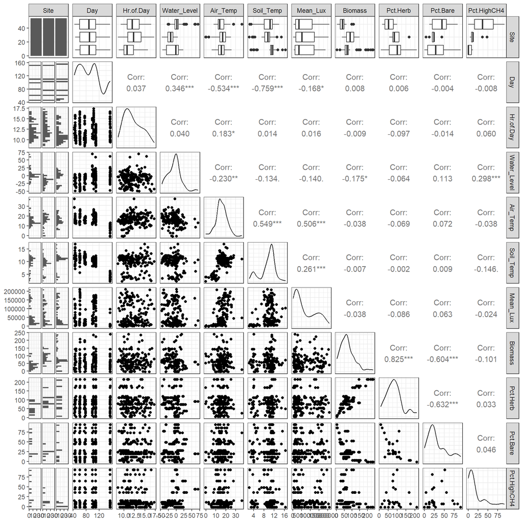

```r
# Filter to covariates of interests: use light data only; only covariates that differ between light and dark are light (obviously) and temperature
corr = visit %>% filter(Light_Dark == "Light") %>%
  select(Site, Days_Since_Thaw, dec.hrs, Water_Level_cm, Mean_Temp_C_true_estimate, Soil_Temp_C, Mean_Lux, Biomass, herb, bare, high_CH4) %>%
  rename(Day = Days_Since_Thaw,
         Hr.of.Day = dec.hrs,
         Water_Level = Water_Level_cm,
         Air_Temp = Mean_Temp_C_true_estimate,
         Soil_Temp = Soil_Temp_C,
         Pct.Herb = herb,
         Pct.Bare = bare,
         Pct.HighCH4 = high_CH4)

ggpairs(corr)
```

I see a few issues here:

1. Days since thaw has a strong relationship with soil temp and, to a lesser extent, air temp. Air temp and soil temp are also correlated, though there is some meaningful variance between them. In my modelling below, I include the variables that make more sense as an explanatory variable. For methane flux, soil temp is more meaningful than day of year; air temp *might* make a difference. For photosynthesis, day of year is probably most meaningful, as it tracks the phenological progression of plants; air temp could also have some effect. For respiration, all 3 variables could have a meaningful effect: plant phenology matters, and both plants and soil microbes could contribute meaningfully to respiration, which we know is affected by temperature.
2. Biomass and percent herbaceous are highly correlated. I initially tried including percent herbaceous in the model selection below for photosynthesis and respiration just to make sure it isn’t offering some marginal extra information, but biomass is the better variable to use. Percent bare is also relatively correlated with both biomass and percent herbaceous. I include it in the respiration and methane models in case it’s capturing something important in soil-air gas exchange.
3. Percent high CH4 is highly unequal between sites, with high (though variable) cover at East and mostly low cover at Mid and West. I still include it in the methane model selection in case it’s capturing something beyond site.

# Modelling Gas Flux

## Approach

So far, I’ve been using generalized additive models (GAMs) to model gas flux. GAMs were Lauren’s first idea, and they seem like a flexible and effective choice of model. Like linear or generalized linear models, GAMs add together the effects of different independent variables on a dependent variable, but unlike LMs and GLMs, the shape of that effect doesn’t need to be constrained to a particular functional form - you can fit any smooth curve (often shortened to “smooth”). I looked through [this](https://r.qcbs.ca/workshop08/book-en/introduction-to-generalized-additive-mixed-models-gamms.html) tutorial to familiarize myself with GAMs initially, and I’ve also benefited from some other internet sources (like Stack Overflow). I’m interested in trying other models as well, particularly boosted regression trees (which have been used to model methane fluxes) or other machine learning approaches, though we may not have enough data to make any of those worthwhile.

One challenge with our dataset is that we have repeated measurements from each collar, and collar ID presumably has a major effect on flux that the other variables aren’t going to fully capture. Statistical theory would say that collar ID should be included as a random effect; however, since we want to predict gas flux across the sites, not just at our collars, we will need models that don’t include collar ID. I’ve included both types of models below.

An important part of model selection is to assess not only how well the model describes the full dataset, but how well it can predict new data. This is a particularly important distinction for our data, since we only have 27 truly independent data points (27 collars). To test model prediction, I use cross validation. There are different types of cross validation, but the general idea is that you pull out a subset of the data (“testing data”), build a model on the rest of the data (“training data”), apply the model to the testing data, and repeat this process systematically so that all of the data gets used equally in training and testing sets. Because the model is tested on “new data” each time, overfitting is properly reflected in the model accuracy. For models that don’t include collar ID, I’ve been doing “27-fold” cross validation in which gas flux from each collar is predicted using data from other collars only. If our collar placement is relatively representative of the sites, this method should give us an estimate of how well we might predict gas flux at an entirely new collar. For models that do include collar ID, I’m doing 27-fold cross validation that doesn’t divide training and testing by collar ID. I’ve written functions that incorporate these cross-validation schemes into best subsets model selection.

Prompted by really low cross-validated accuracies for methane, I’ve found a couple ways to significantly reduce overfitting (with the help of Stack Overflow). One is to change the method from GCV (Generalized Cross Validation), the default, to REML (Restricted Maximum Likelihood). The other is to limit the value of K, which determines how many bends the smooths can have. K = 4 generally seems to give the best model accuracy. Limiting K makes sense physically: the predictor variables we’re measuring are unlikely to have super complicated relationships to gas flux, especially within our limited dataset. I think the extra bends you get in the methane model when you don’t limit K are probably just artifacts from the more extreme datapoints - they clearly bring down the predictive accuracy of the model.

Another update I’ve made since the previous version of this analysis document is log-transforming the gas flux values. Methane flux clearly needed to be transformed, but I’ve realized that since methane, photosynthesis, and respiration are all primarily chemical processes, they’re probably all driven more by multiplicative effects than by additive ones. For example, if the soil temp drops to near 0 degrees, we would expect all of the respiration fluxes to be multiplied by some very small coefficient, regardless of how big they were initially. An additive model would handle this clumsily at best - we might see a big negative partial effect at low soil temperatures that overstates the drop in respiration for collars with little vegetation and understates the drop for collars with a lot of vegetation. See the example formulation below. Biomass is the one variable in my mind that doesn’t make much sense in this multiplicative framework: photosynthesis and respiration likely do scale linearly with biomass. For that reason, I use log-transformed biomass in the models below to aid in interpretation.

$Flux = C*e^{f(SoilTemp)}*e^{f(WaterLevel)}$ –> $ln(Flux) = f(SoilTemp) + f(WaterLevel) + C$ rather than $Flux = f(SoilTemp) + f(WaterLevel) + C$

Another way to go about this would be to use a log link function in the GAM rather than log-transforming the raw data. The difference is that a link function says nothing about the assumed distribution of residuals; it only sets the relationship between predictors and response. For example, for count data, we could use a log link function and a Poisson family for the residuals. The residual distribution is used in the maximum likelihood estimation that finds the best fit model, and can change the best fit model considerably. By log-transforming the data, I’m essentially assuming a log-normal residual distribution. There might be another residual family that makes more sense; I tried changing the family to Gamma for photosynthesis and methane, but that gave me a worse model fit for methane (photosynthesis didn’t change much).

One limitation of log models is that they can’t handle negatives; some of our drier measurements have had slightly negative methane fluxes, and a few photosynthetic fluxes came out slightly positive. I’ve added a small constant to all methane fluxes, and flipped the sign on photosynthetic fluxes (after subtracting a small constant). For these constants, I decided on 1 unit at the smallest place value that makes everything positive (e.g., 1, 0.1, 0.01), which seems relatively unbiased? Here’s how log transformation affects the distributions of fluxes:

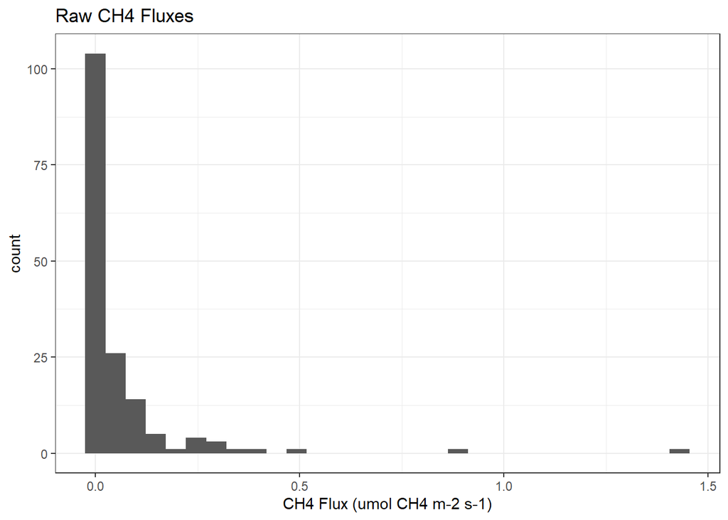

```r
# Separate out light and dark measurements again (updating since more variables have been added to 'visit')
light = visit %>%
  filter(Light_Dark == "Light")
dark = visit %>%
  filter(Light_Dark == "Dark")
# Calculate photosynthesis by subtracting dark from light for corresponding measurements (repeating as above)
photo = data.frame(CollarID = light$CollarID,
                   Date = light$Date,
                   Site = light$Site,
                   Photosynthesis_umolCO2_m.2_s.1 = light$CO2_flux_umol_m.2_sec.1 - dark$CO2_flux_umol_m.2_sec.1)

photo_join = light %>% inner_join(photo, by = c("CollarID", "Date", "Site"))
photo_join$CollarID = as.factor(photo_join$CollarID)
photo_join$Site = as.factor(photo_join$Site)

# Create pared down table with light/dark averaged methane, shorten variable names
ch4.sub = dark %>% select(CollarID, Water_Level_cm, log.Biomass, Site, Soil_Temp_C, bare, high_CH4, Days_Since_Thaw)
ch4.sub$AirTemp = (dark$Mean_Temp_C_true_estimate + light$Mean_Temp_C_true_estimate)/2
ch4.sub$Hr.of.Day = (dark$dec.hrs + light$dec.hrs)/2
ch4.sub$raw.CH4 = (dark$CH4_flux_umol_m.2_sec.1 + light$CH4_flux_umol_m.2_sec.1)/2
ch4.sub$log.CH4 = log(ch4.sub$raw.CH4 + 0.01)

ch4.sub = ch4.sub %>%
  rename(WL = Water_Level_cm,
         BM = log.Biomass,
         SoilTemp = Soil_Temp_C,
         Bare = bare)

### Log-transform CH4 flux, photosynthetic CO2 flux, and respiration (dark) CO2 flux
ch4.sub$log.CH4 = log(ch4.sub$raw.CH4 + 0.01) # Add 0.01 to make all values positive (lowest flux is -0.0057); log model fit (R^2) improves noticeably when I lower the delta between the added constant and the most negative flux value (e.g. going from 0.01 to 0.006 for constant). This probably doesn't matter much - most of the effect on the model is probably at the low end where all the values are tiny anyway. Really what this constant does is it bounds the range of possible flux values - if the model were to set the log value to -inf, then the predicted flux would be -0.006. I'm not sure if it's best practice to bound the model very close to the lowest measured value or leave a bit of room for lower values. For now, it seems like adding one unit to the furthest decimal place that makes all values positive is a reasonable approach.

photo_join$log.photo = log(-(photo_join$Photosynthesis_umolCO2_m.2_s.1 - 1)) # a few photosynthetic fluxes are slightly positive - highest is ~0.8

dark$log.resp = log(dark$CO2_flux_umol_m.2_sec.1) # no dark CO2 fluxes are negative

ggplot(ch4.sub, aes(x = raw.CH4)) + geom_histogram() + labs(title = "Raw CH4 Fluxes", x = "CH4 Flux (umol CH4 m-2 s-1)") # non-log values
```

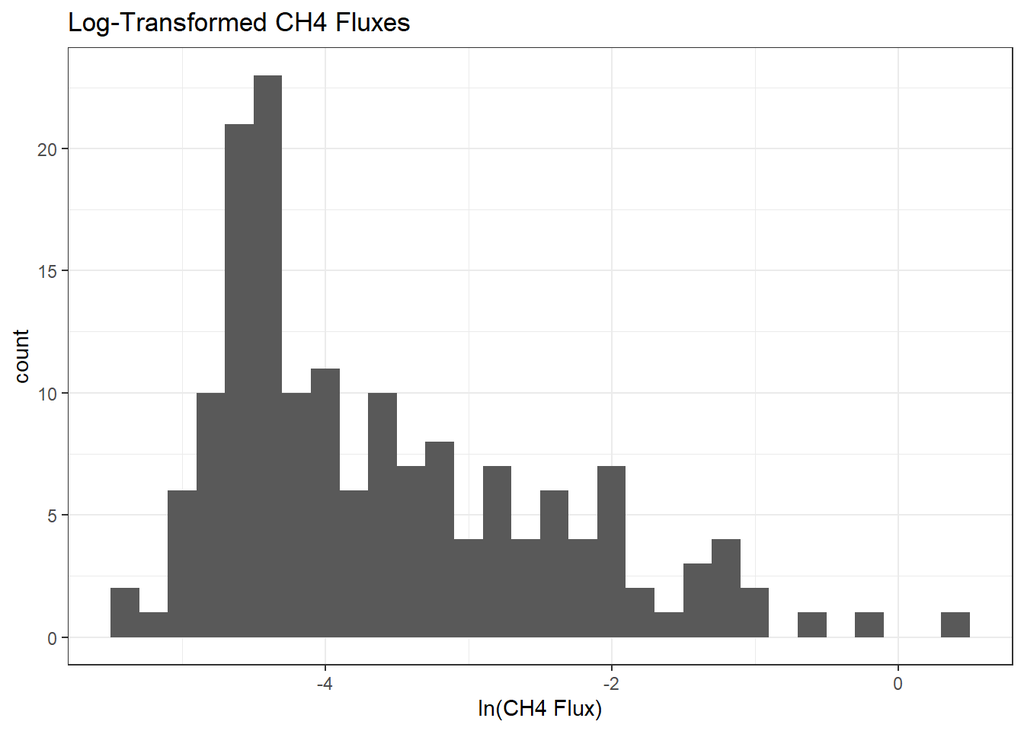

```r
ggplot(ch4.sub, aes(x = log.CH4)) + geom_histogram() + labs(title = "Log-Transformed CH4 Fluxes", x = "ln(CH4 Flux)") # log values (still not normal but closer)
```

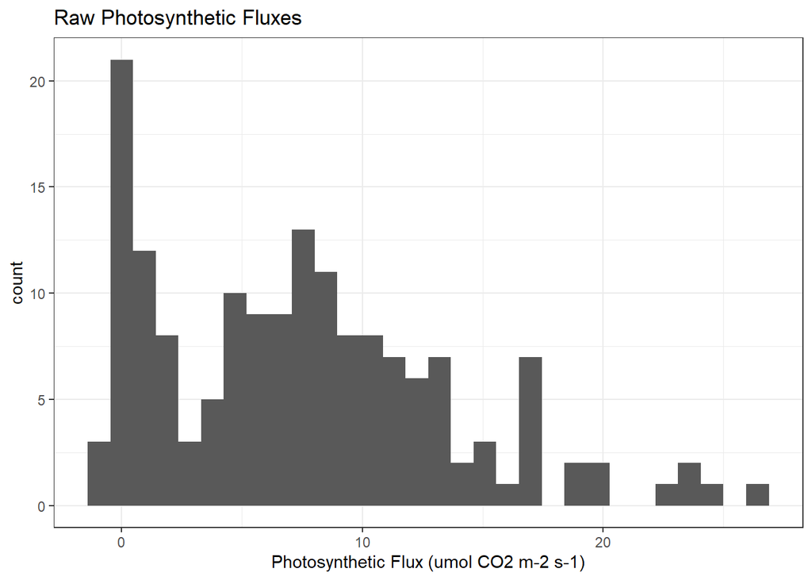

```r
ggplot(photo_join, aes(x = -Photosynthesis_umolCO2_m.2_s.1)) + geom_histogram() + labs(title = "Raw Photosynthetic Fluxes", x = "Photosynthetic Flux (umol CO2 m-2 s-1)") # non-log values
```

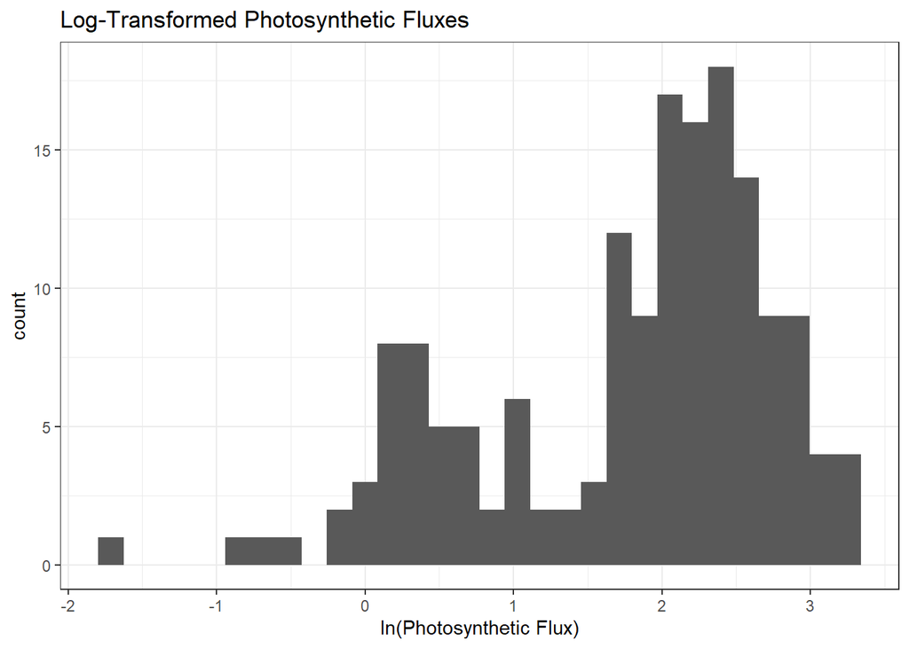

```r
ggplot(photo_join, aes(x = log.photo)) + geom_histogram() + labs(title = "Log-Transformed Photosynthetic Fluxes", x = "ln(Photosynthetic Flux)") # log values (still not normal but closer)
```

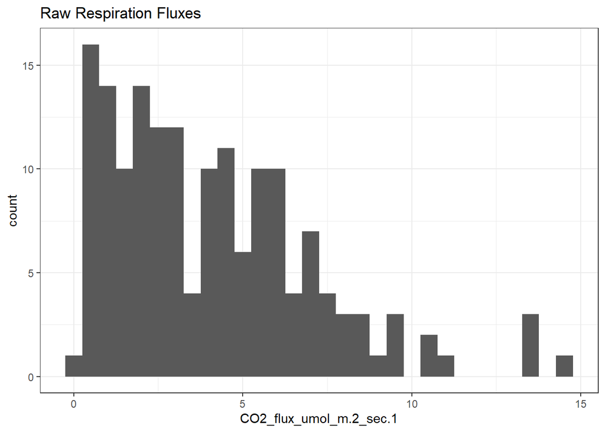

```r
ggplot(dark, aes(x = CO2_flux_umol_m.2_sec.1)) + geom_histogram() + labs(title = "Raw Respiration Fluxes", "CO2 Flux (umol CO2 m-2 s-1)") # non-log values
```

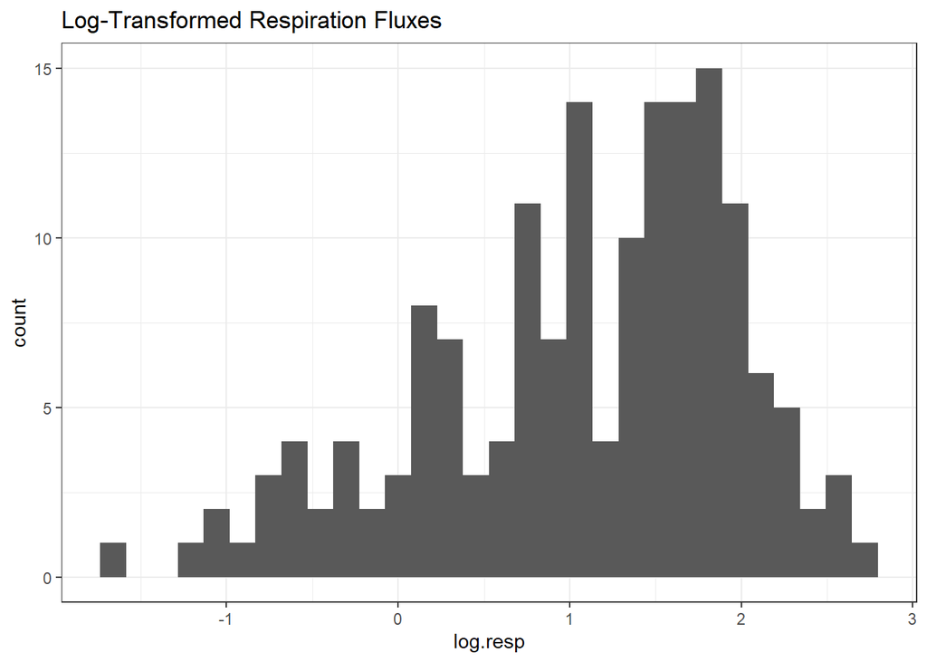

```r
ggplot(dark, aes(x = log.resp)) + geom_histogram() + labs(title = "Log-Transformed Respiration Fluxes", "ln(CO2 Flux)") # log values (still not normal but closer)
```

The distribution of methane fluxes still isn’t normal after log transformation, but it’s a lot closer. Log-transforming photosynthetic and respiration fluxes converts both from right-skewed to somewhat left-skewed.

I’ve built a set of functions to choose the best subset of variables for explaining flux. The functions produce three diagnostics for each model: $R^2$, mean average error (MAE), and root mean squared (RMS) error; these diagnostics are produced for both the log values (what the model is built off of) and the raw values. I also included a lower cutoff option for the non-cross validated model $R^2$. With a lot of potential variables, the functions take a long time to run; it saves some time and computing power to check the $R^2$ first and just throw out the models that miss the cutoff before going through the rest of the calculations. I’ve also included options for only including certain numbers of variables in the model. I’m sure there are other ways to improve efficiency; there might be ways to incorporate `caret`, but I’m not sure how to incorporate my specific cross validation scheme.

```r
# Build a GAM formula for a variable set with undetermined length
build.form = function(dep, ind, k, dataset){
  # dep = dependent variable name, ind = vector of independent variable names, k = value of k for each numeric variable smooth in GAM formula, dataset = name of data frame
  begin = paste(dep,"~")  # start formula
  for (i in 1:length(ind)){
     if (i != 1){   # add a plus sign for each variable after the first
       begin = paste(begin, "+")
     }
     if (ind[i] %in% c("CollarID","Transect","CollarID, Lux")){   # add random effect for CollarID, Transect, or CollarID slope with Lux
       begin = paste(begin, 's(', ind[i], ', bs = "re")')
     }
     else if (is.numeric(dataset[,ind[i]])){   # add smooth for numeric variable
       begin = paste(begin, "s(", ind[i], ", k = ",k,")")
     }
     else { begin = paste(begin, ind[i]) }  # add non-smoothed effect for other non-numeric variable (e.g., site)
  }
  return(as.formula(begin))
}

# Paste variable names together (for model representation in a table)
paste_all = function(ind){
  # ind = vector of independent variable names
  vars = ""
  for (i in 1:length(ind)){
    vars = paste(ind[i], vars, sep = "  ")
  }
  return(vars)
}

# Run CV (collar-wise if Collar ID isn't included); generate R^2, MAE, RMS error stats; if it's a log model, generate same stats for raw (non-log) predictions
collar.cv = function(dep, ind, dataset, is.log, raw.name, offset, k){
  # dep = dependent variable name; ind = vector of independent variable names; dataset = name of data frame; is.log = whether it's a log model (TRUE/FALSE); raw.name = name of variable representing raw (non-log) values of dependent variable, if model is a log model; offset = value added to raw values to remove negatives before log transformation (used for back transformation of predictions); k = value of k for each numeric variable smooth in GAM formula

  # Create an empty list to collect stats, set a count to index in list, set model formula
  full.preds = list()
  count = 1
  form = build.form(dep, ind, k, dataset)

  # Path for models with Collar ID (random effect)
  if ("CollarID" %in% ind){
    u = rep(1,27)  # vector for number of unique collars in each testing group
    rounds = nrow(dataset)/27  # rounds of data collection = number of observations in each test set (**assumes even sampling design**)
    while (1 %in% u){  # Randomly order the dataset, see if resulting 27 divisions leave any test sets with only one collar (which would mean that collar isn't in the training set); if any do, reorder the dataset
      samp = sample(1:nrow(dataset), nrow(dataset), replace = FALSE)
      for (i in 1:27){
        u[i] = length(unique(dataset[samp[((i-1)*rounds+1):(i*rounds)],"CollarID"]))
      }
    }

    # Run CV using divisions from random order above, generate predicted vs actual values (log and raw, if relevant)
    for (i in 1:27){
      train = dataset[-samp[((i-1)*rounds+1):(i*rounds)],]
      test = dataset[samp[((i-1)*rounds+1):(i*rounds)],]
      mod = gam(form, data = train, method = "REML")
      preds = predict.gam(mod, test)
      full.preds[[count]] = data.frame(Predicted = preds, Actual = test[,dep])
      if (is.log == TRUE){
        full.preds[[count]][,"Predicted.raw"] = exp(preds) - offset
        full.preds[[count]][,"Actual.raw"] = test[,raw.name]
      }
      count = count + 1
    }
  }

  # Path for models without random effect
  else{
    # Run collar-wise CV, generate predicted vs actual values (log and raw, if relevant)
    for (collar in unique(dataset[,"CollarID"])){
      train = dataset %>% filter(CollarID != collar)
      test = dataset %>% filter(CollarID == collar)
      mod = gam(form, data = train, method = "REML")
      preds = predict.gam(mod, test)
      full.preds[[count]] = data.frame(Predicted = preds, Actual = test[,dep])
      if (is.log == TRUE){
        full.preds[[count]][,"Predicted.raw"] = exp(preds) - offset
        full.preds[[count]][,"Actual.raw"] = test[,raw.name]
      }
      count = count + 1
    }
  }

  # Create 1-row table of diagnostics (R2, MAE, RMS)
  full.preds = bind_rows(full.preds)
  accuracy.stats = data.frame(Size = length(ind),
                              Variables = paste_all(ind),
                              R2 = cor(full.preds$Predicted, full.preds$Actual)^2,
                              MAE = mean(abs(full.preds$Predicted - full.preds$Actual)),
                              RMS = sqrt(mean((full.preds$Predicted - full.preds$Actual)^2)))

  # If it's a log model, add raw diagnostics
  if (is.log == TRUE){
    accuracy.stats$R2.raw = cor(full.preds$Predicted.raw, full.preds$Actual.raw)^2
    accuracy.stats$MAE.raw = mean(abs(full.preds$Predicted.raw - full.preds$Actual.raw))
    accuracy.stats$RMS.raw = sqrt(mean((full.preds$Predicted.raw - full.preds$Actual.raw)^2))
  }

  return(accuracy.stats)
}

# Find the best model from all combinations of variables - return sorted table with accuracy stats
best.sub = function(dep, ind, dataset, min.var = 1, max.var = NA, is.log = FALSE, raw.name = NA, offset = 0, k = 4, sort.by = "MAE", rsq.min = 0.5){
  # dep = dependent variable name; ind = vector of independent variable names; dataset = name of data frame; min.var = minimum number of variables to include in model (default 1); max.var = maximum number of variables to include in model (default NA - max set to max number of variables in 'ind'); is.log = whether the model is a log model (TRUE/FALSE); raw.name = name of variable representing raw (non-log) values of dependent variable, if model is a log model; offset = value added to raw values to remove negatives before log transformation (used for back transformation of predictions); k = value of k for each numeric variable smooth in GAM formula; sort.by = diagnostic to sort table by (R2, MAE, RMS, R2.raw, MAE.raw, or RMS.raw); rsq.min = minimum r-squared for non-cross validated model - models with lower value are thrown out before cross validation

  # Create empty list for accuracy stats of candidate models
  acc = list()
  count = 1

  if (is.na(max.var)){
    max.var = length(ind)
  }

  # Loop through each possible number of variables in model
  for (nvar in min.var:max.var){
    combos = combn(ind, nvar)
    # Loop through each combination of variables for given number of variables
    for (i in 1:ncol(combos)){
      # Run model on full data
      mod.full = gam(build.form(dep, combos[,i], k, dataset), data = dataset, method = "REML")
      # if R2 is above minimum, run CV and get diagnostic stats
      if (summary(mod.full)$r.sq >= rsq.min){
        acc[[count]] = collar.cv(dep, combos[,i], dataset, is.log, raw.name, offset, k)
        count = count + 1 }
    }
  }

  # Combine diagnostics for each candidate model
  acc = bind_rows(acc)
  return(arrange(acc, .data[[sort.by]]))
}
```

## Photosynthesis

I’m considering photosynthesis and respiration separately rather than looking at net CO2 exchange, since the two processes have different drivers. In the models below, photosynthetic flux values are shown as positive - that is, more $CO_2$ drawdown = greater positive flux.

### Without Collar ID

My candidate variables for photosynthesis models without Collar ID are light intensity, water level, time of year (days since thaw), log biomass, site, air temperature (corrected), and hour of the day.

```r
# Make photosynthesis values positive
photo_join$neg.photo = -photo_join$Photosynthesis_umolCO2_m.2_s.1
# Create pared down table, shorten variable names
photo.sub = photo_join %>% select(CollarID, Photosynthesis_umolCO2_m.2_s.1, log.photo, neg.photo, Mean_Lux, Water_Level_cm, Days_Since_Thaw, log.Biomass, Site, Mean_Temp_C_true_estimate, dec.hrs) %>%
  rename(Lux = Mean_Lux,
         WL = Water_Level_cm,
         Day = Days_Since_Thaw,
         BM = log.Biomass,
         AirTemp = Mean_Temp_C_true_estimate,
         Hr.of.Day = dec.hrs,
         raw.photo = Photosynthesis_umolCO2_m.2_s.1)

# Run model selection (set min R2 = 0.75)
photo.select = best.sub("log.photo", c("Lux", "WL", "Day", "BM", "Site", "AirTemp", "Hr.of.Day"), photo.sub, is.log = TRUE, raw.name = "neg.photo", offset = 1, rsq.min = 0.7)

kable(photo.select, digits = 2)
```

| Size | Variables | R2 | MAE | RMS | R2.raw | MAE.raw | RMS.raw |
| --- | --- | --- | --- | --- | --- | --- | --- |
| 6 | AirTemp Site BM Day WL Lux | 0.73 | 0.36 | 0.52 | 0.72 | 2.45 | 3.34 |
| 6 | Hr.of.Day Site BM Day WL Lux | 0.74 | 0.36 | 0.51 | 0.70 | 2.50 | 3.41 |
| 5 | Site BM Day WL Lux | 0.73 | 0.36 | 0.52 | 0.73 | 2.45 | 3.34 |
| 5 | AirTemp BM Day WL Lux | 0.73 | 0.37 | 0.52 | 0.70 | 2.50 | 3.46 |
| 7 | Hr.of.Day AirTemp Site BM Day WL Lux | 0.73 | 0.37 | 0.52 | 0.70 | 2.50 | 3.39 |
| 4 | BM Day WL Lux | 0.73 | 0.37 | 0.52 | 0.70 | 2.51 | 3.48 |
| 5 | Hr.of.Day BM Day WL Lux | 0.73 | 0.37 | 0.52 | 0.65 | 2.61 | 3.64 |
| 6 | Hr.of.Day AirTemp BM Day WL Lux | 0.73 | 0.37 | 0.52 | 0.66 | 2.59 | 3.60 |
| 4 | AirTemp BM Day WL | 0.70 | 0.39 | 0.54 | 0.62 | 2.74 | 3.88 |
| 5 | AirTemp Site BM Day WL | 0.71 | 0.39 | 0.54 | 0.64 | 2.74 | 3.79 |
| 5 | Hr.of.Day AirTemp BM Day WL | 0.70 | 0.40 | 0.54 | 0.59 | 2.84 | 3.96 |
| 6 | Hr.of.Day AirTemp Site BM Day WL | 0.71 | 0.40 | 0.54 | 0.63 | 2.78 | 3.78 |
| 5 | Hr.of.Day AirTemp BM Day Lux | 0.67 | 0.41 | 0.57 | 0.63 | 2.77 | 3.79 |
| 5 | Hr.of.Day Site BM Day WL | 0.69 | 0.41 | 0.55 | 0.59 | 2.88 | 3.99 |
| 4 | Hr.of.Day BM Day WL | 0.68 | 0.41 | 0.56 | 0.55 | 2.88 | 4.17 |
| 4 | Site BM Day WL | 0.69 | 0.42 | 0.56 | 0.60 | 2.93 | 4.00 |
| 3 | BM Day WL | 0.68 | 0.42 | 0.56 | 0.58 | 2.92 | 4.11 |
| 6 | Hr.of.Day AirTemp Site BM WL Lux | 0.65 | 0.45 | 0.59 | 0.61 | 2.89 | 3.85 |

It looks like the best model, with an $R^2$ of 0.73, uses **log biomass, days since thaw, water level, light intensity, and site**. The best model with 4 variables - i.e., excluding site - has basically the same diagnostics for the log values but a little bit worse diagnostics for the raw values; it seems that site *may* have a small but real effect. Interestingly, the best model with 3 variables removes light intensity. Let’s see the summary and plots for the top model:

```r
gam_phot = gam(log.photo ~ s(Lux, k=4) + s(WL, k=4) + s(Day, k=4) + s(BM, k=4) + Site, data = photo.sub, method = "REML")
summary(gam_phot)
```

```
##
## Family: gaussian
## Link function: identity
##
## Formula:
## log.photo ~ s(Lux, k = 4) + s(WL, k = 4) + s(Day, k = 4) + s(BM,
##     k = 4) + Site
##
## Parametric coefficients:
##             Estimate Std. Error t value Pr(>|t|)
## (Intercept)  1.93224    0.07525  25.679  < 2e-16 ***
## SiteMid     -0.34140    0.12132  -2.814  0.00555 **
## SiteWest    -0.13272    0.10051  -1.321  0.18867
## ---
## Signif. codes:  0 '***' 0.001 '**' 0.01 '*' 0.05 '.' 0.1 ' ' 1
##
## Approximate significance of smooth terms:
##          edf Ref.df     F  p-value
## s(Lux) 2.735  2.946 12.60 6.17e-07 ***
## s(WL)  2.686  2.925 18.08  < 2e-16 ***
## s(Day) 2.803  2.967 45.87  < 2e-16 ***
## s(BM)  1.000  1.001 83.80  < 2e-16 ***
## ---
## Signif. codes:  0 '***' 0.001 '**' 0.01 '*' 0.05 '.' 0.1 ' ' 1
##
## R-sq.(adj) =  0.772   Deviance explained = 78.8%
## -REML = 127.69  Scale est. = 0.22519   n = 162
```

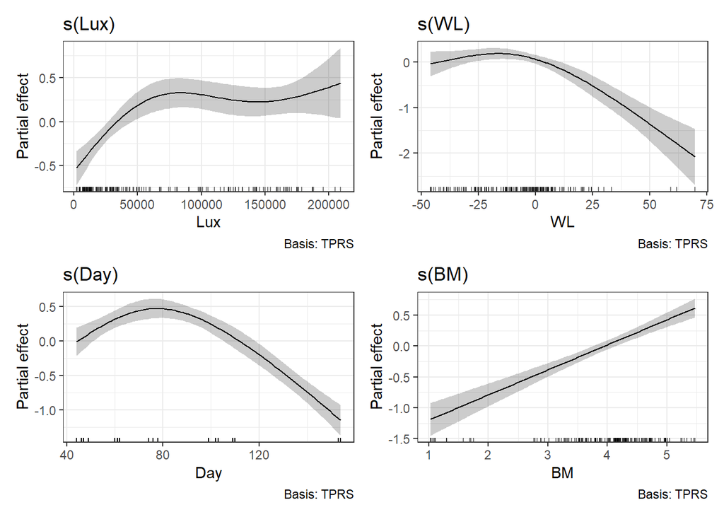

```r
draw(gam_phot)
```

```r
concurvity(gam_phot)
```

```
##               para    s(Lux)     s(WL)    s(Day)     s(BM)
## worst    0.8012044 0.4405556 0.4783270 0.4354409 0.4151462
## observed 0.8012044 0.4259951 0.2180429 0.3491906 0.2034095
## estimate 0.8012044 0.2470130 0.4117660 0.3922906 0.2075176
```

```r
# concurvity(gam_phot, full = FALSE)
```

Finally, I plotted predicted versus actual values:

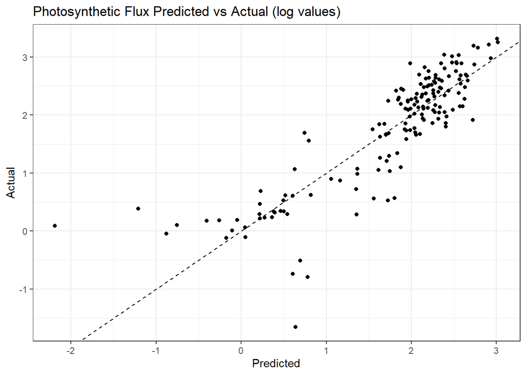

```r
# Run CV (collar-wise if Collar ID isn't included); return log and raw predictions along with actual values
collar.cv.full = function(dep, ind, dataset, is.log = TRUE, raw.name, offset, k = 4){
  # dep = dependent variable name; ind = vector of independent variable names; dataset = name of data frame; is.log = whether it's a log model (TRUE/FALSE); raw.name = name of variable representing raw (non-log) values of dependent variable, if model is a log model; offset = value added to raw values to remove negatives before log transformation (used for back transformation of predictions); k = value of k for each numeric variable smooth in GAM formula

  # Create an empty list to collect stats, set a count to index in list, set model formula
  full.preds = list()
  count = 1
  form = build.form(dep, ind, k, dataset)

  # Path for models with Collar ID (random effect)
  if (("CollarID" %in% ind)|("CollarID, Lux" %in% ind)){
    u = rep(1,27)  # vector for number of unique collars in each testing group
    rounds = nrow(dataset)/27  # rounds of data collection = number of observations in each test set (**assumes even sampling design**)
    while (1 %in% u){  # Randomly order the dataset, see if resulting 27 divisions leave any test sets with only one collar (which would mean that collar isn't in the training set); if any do, reorder the dataset
      samp = sample(1:nrow(dataset), nrow(dataset), replace = FALSE)
      for (i in 1:27){
        u[i] = length(unique(dataset[samp[((i-1)*rounds+1):(i*rounds)],"CollarID"]))
      }
    }

    # Run CV using divisions from random order above, generate predicted vs actual values (log and raw, if relevant)
    for (i in 1:27){
      train = dataset[-samp[((i-1)*rounds+1):(i*rounds)],]
      test = dataset[samp[((i-1)*rounds+1):(i*rounds)],]
      mod = gam(form, data = train, method = "REML")
      preds = predict.gam(mod, test)
      full.preds[[count]] = data.frame(Predicted = preds, Actual = test[,dep])
      if (is.log == TRUE){
        full.preds[[count]][,"Predicted.raw"] = exp(preds) - offset
        full.preds[[count]][,"Actual.raw"] = test[,raw.name]
      }
      count = count + 1
    }
  }

  # Path for models without random effect
  else{
    # Run collar-wise CV, generate predicted vs actual values (log and raw, if relevant)
    for (collar in unique(dataset[,"CollarID"])){
      train = dataset %>% filter(CollarID != collar)
      test = dataset %>% filter(CollarID == collar)
      mod = gam(form, data = train, method = "REML")
      preds = predict.gam(mod, test)
      full.preds[[count]] = data.frame(Predicted = preds, Actual = test[,dep])
      if (is.log == TRUE){
        full.preds[[count]][,"Predicted.raw"] = exp(preds) - offset
        full.preds[[count]][,"Actual.raw"] = test[,raw.name]
      }
      count = count + 1
    }
  }

  # Create 1-row table of diagnostics (R2, MAE, RMS)
  full.preds = bind_rows(full.preds)
  return(full.preds)
}

photo.cv = collar.cv.full("log.photo", c("WL", "BM", "Lux", "Day", "Site"), photo.sub, raw.name = "neg.photo", offset = 1)

ggplot(photo.cv, aes(x = Predicted, y = Actual)) +
  geom_point() +
  geom_abline(slope = 1, intercept = 0, lty = "dashed") +
  labs(title = "Photosynthetic Flux Predicted vs Actual (log values)")
```

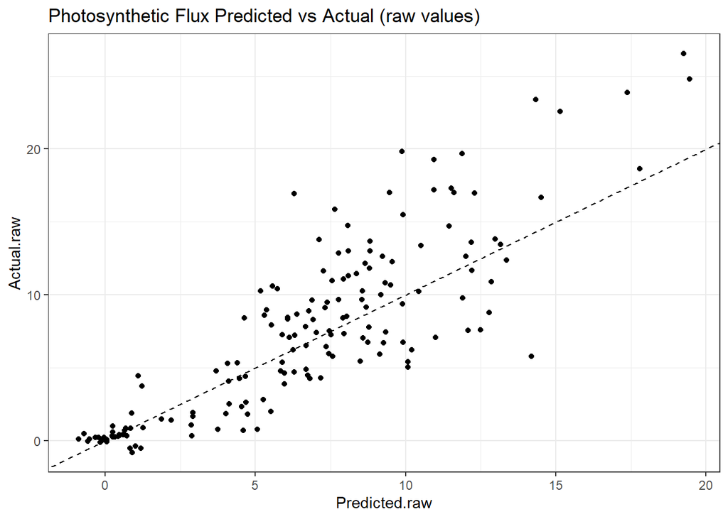

```r
ggplot(photo.cv, aes(x = Predicted.raw, y = Actual.raw)) +
  geom_point() +
  geom_abline(slope = 1, intercept = 0, lty = "dashed") +
  labs(title = "Photosynthetic Flux Predicted vs Actual (raw values)")
```

These plots look decent, but it seems that the model is mostly underpredicting the high photosynthetic flux values. The “outliers” on the low flux end probably have an outsized effect on the model with the log transformation.

### With Collar ID as a Random Effect

For this next model selection, I included the random effect from Collar ID and tried all of the same additional variables except biomass (highly related to Collar ID) and site (redundant with Collar ID). Here’s what comes out:

```r
photo.select2 = best.sub("log.photo", c("Lux", "WL", "Day", "AirTemp", "Hr.of.Day", "CollarID"), photo.sub, is.log = TRUE, raw.name = "neg.photo", offset = 1, rsq.min = 0.70)
kable(photo.select2, digits = 2)
```

| Size | Variables | R2 | MAE | RMS | R2.raw | MAE.raw | RMS.raw |
| --- | --- | --- | --- | --- | --- | --- | --- |
| 5 | CollarID Hr.of.Day Day WL Lux | 0.74 | 0.36 | 0.50 | 0.70 | 2.41 | 3.45 |
| 6 | CollarID Hr.of.Day AirTemp Day WL Lux | 0.74 | 0.37 | 0.51 | 0.70 | 2.44 | 3.46 |
| 5 | CollarID AirTemp Day WL Lux | 0.73 | 0.37 | 0.52 | 0.70 | 2.47 | 3.50 |
| 4 | CollarID Day WL Lux | 0.72 | 0.37 | 0.52 | 0.71 | 2.50 | 3.48 |
| 4 | CollarID AirTemp Day Lux | 0.68 | 0.40 | 0.56 | 0.63 | 2.70 | 3.81 |
| 4 | CollarID AirTemp Day WL | 0.70 | 0.40 | 0.54 | 0.58 | 2.86 | 4.04 |
| 4 | CollarID Hr.of.Day Day Lux | 0.66 | 0.40 | 0.58 | 0.61 | 2.69 | 3.90 |
| 5 | CollarID Hr.of.Day AirTemp Day Lux | 0.67 | 0.40 | 0.57 | 0.62 | 2.72 | 3.86 |
| 3 | CollarID Day Lux | 0.66 | 0.41 | 0.57 | 0.63 | 2.75 | 3.88 |
| 4 | CollarID Hr.of.Day Day WL | 0.69 | 0.41 | 0.56 | 0.52 | 2.99 | 4.31 |
| 5 | CollarID Hr.of.Day AirTemp Day WL | 0.70 | 0.42 | 0.55 | 0.56 | 2.96 | 4.09 |
| 3 | CollarID AirTemp Day | 0.65 | 0.42 | 0.58 | 0.55 | 2.97 | 4.21 |
| 4 | CollarID Hr.of.Day AirTemp Day | 0.65 | 0.43 | 0.58 | 0.55 | 3.02 | 4.17 |
| 3 | CollarID Day WL | 0.66 | 0.44 | 0.58 | 0.50 | 3.11 | 4.42 |
| 5 | CollarID Hr.of.Day AirTemp WL Lux | 0.64 | 0.45 | 0.60 | 0.56 | 2.99 | 4.10 |
| 4 | CollarID AirTemp WL Lux | 0.64 | 0.45 | 0.60 | 0.57 | 2.98 | 4.08 |

**Collar ID, days since thaw, water level, and light intensity** seem to be the important variables. Adding hour of day and/or air temperature improves the model *very* marginally, but the degree is small enough that I don’t think it’s worth moving forward with those variables. Interestingly, these models don’t improve on the cross-validated accuracy of the model without collar ID. Maybe including collar isn’t so important for photosynthetic flux after all.

Let’s look at the model summary and smooths:

```r
gam_phot2 = gam(log.photo ~ s(Lux, k=4) + s(WL, k=4) + s(Day, k=4) + s(CollarID, bs = "re"), data = photo.sub, method = "REML")
summary(gam_phot2)
```

```
##
## Family: gaussian
## Link function: identity
##
## Formula:
## log.photo ~ s(Lux, k = 4) + s(WL, k = 4) + s(Day, k = 4) + s(CollarID,
##     bs = "re")
##
## Parametric coefficients:
##             Estimate Std. Error t value Pr(>|t|)
## (Intercept)  1.77420    0.08013   22.14   <2e-16 ***
## ---
## Signif. codes:  0 '***' 0.001 '**' 0.01 '*' 0.05 '.' 0.1 ' ' 1
##
## Approximate significance of smooth terms:
##                edf Ref.df      F  p-value
## s(Lux)       2.707  2.923 11.698 1.69e-06 ***
## s(WL)        2.606  2.842 11.861 1.10e-06 ***
## s(Day)       2.832  2.974 49.494  < 2e-16 ***
## s(CollarID) 20.207 26.000  3.768  < 2e-16 ***
## ---
## Signif. codes:  0 '***' 0.001 '**' 0.01 '*' 0.05 '.' 0.1 ' ' 1
##
## R-sq.(adj) =  0.787   Deviance explained = 82.4%
## -REML = 139.01  Scale est. = 0.21089   n = 162
```

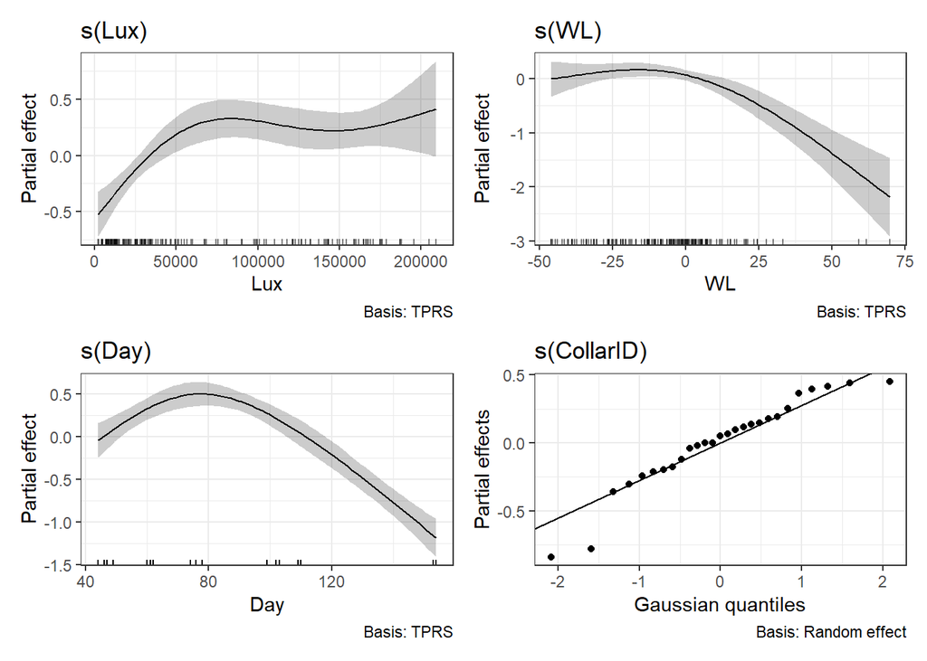

```r
draw(gam_phot2)
```

The collar partial effects mostly follow the Gaussian quantiles, except for 2 collars with particularly negative effects. When I tried running the model with hour of day and air temp, hour of day did have a low P-value (0.004), though air temp did not. It looks like there could be a *slight* increase in photosynthetic flux over the course of the day, other variables being equal. Next, I checked for concurvity issues with these variables:

```r
concurvity(gam_phot2)
```

```
##          para   s(Lux)     s(WL)    s(Day) s(CollarID)
## worst       1 0.642377 0.8050106 0.5459835  1.00000000
## observed    1 0.548271 0.6100431 0.4074471  0.02328448
## estimate    1 0.588037 0.7720439 0.5329825  0.11643305
```

```r
# concurvity(gam_phot2, full = FALSE)
```

Here are predicted versus actual values:

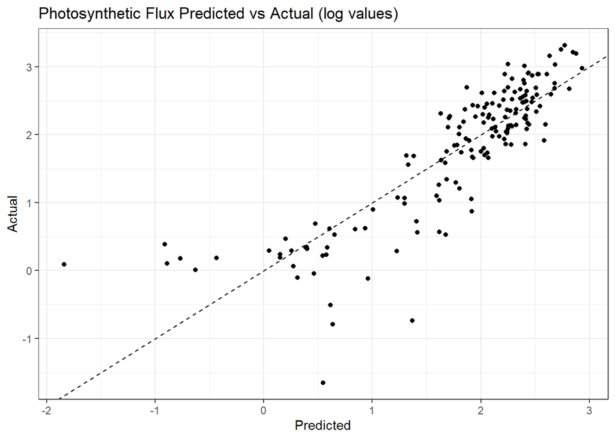

```r
photo.cv2 = collar.cv.full("log.photo", c("WL", "Lux", "Day", "CollarID"), photo.sub, raw.name = "neg.photo", offset = 1)

ggplot(photo.cv2, aes(x = Predicted, y = Actual)) +
  geom_point() +
  geom_abline(slope = 1, intercept = 0, lty = "dashed") +
  labs(title = "Photosynthetic Flux Predicted vs Actual (log values)")
```

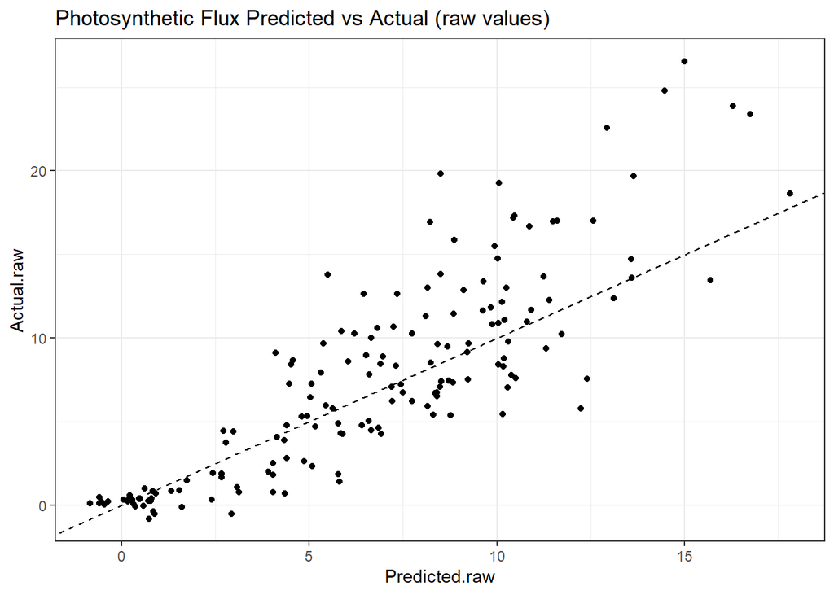

```r
ggplot(photo.cv2, aes(x = Predicted.raw, y = Actual.raw)) +
  geom_point() +
  geom_abline(slope = 1, intercept = 0, lty = "dashed") +
  labs(title = "Photosynthetic Flux Predicted vs Actual (raw values)")
```

These plots look very similar to those for the previous model.